# Fineract Platform Documentation

##### org.apache.fineract.infrastructure.codes.exception

| Classes | Abstract | Ce | Ca | I | A | D |
| --- | --- | --- | --- | --- | --- | --- |
| 3 | 0 | 2 | 10 | 0.17 | 0.00 | 0.83 |

**Depends on (1):** `org.apache.fineract.infrastructure.core.exception`

**Depended on by (6):** `org.apache.fineract.accounting.rule.service`, `org.apache.fineract.infrastructure.codes.domain`, `org.apache.fineract.infrastructure.codes.service`, `org.apache.fineract.portfolio.client.service`, `org.apache.fineract.portfolio.collateral.service`, `org.apache.fineract.portfolio.loanorigination.serialization`

##### org.apache.fineract.infrastructure.configuration.exception

| Classes | Abstract | Ce | Ca | I | A | D |
| --- | --- | --- | --- | --- | --- | --- |
| 4 | 0 | 2 | 8 | 0.20 | 0.00 | 0.80 |

**Depends on (1):** `org.apache.fineract.infrastructure.core.exception`

**Depended on by (4):** `org.apache.fineract.infrastructure.configuration.domain`, `org.apache.fineract.infrastructure.configuration.serialization`, `org.apache.fineract.infrastructure.configuration.service`, `org.apache.fineract.portfolio.loanorigination.service`

##### org.apache.fineract.infrastructure.contentstore.detector

| Classes | Abstract | Ce | Ca | I | A | D |
| --- | --- | --- | --- | --- | --- | --- |
| 7 | 2 | 1 | 6 | 0.14 | 0.29 | 0.57 |

**Depends on (1):** `org.apache.fineract.infrastructure.contentstore.exception`

**Depended on by (4):** `org.apache.fineract.infrastructure.contentstore.policy`, `org.apache.fineract.infrastructure.contentstore.service`, `org.apache.fineract.infrastructure.documentmanagement.api`, `org.apache.fineract.infrastructure.documentmanagement.service`

##### org.apache.fineract.infrastructure.contentstore.exception

| Classes | Abstract | Ce | Ca | I | A | D |
| --- | --- | --- | --- | --- | --- | --- |
| 5 | 0 | 1 | 9 | 0.10 | 0.00 | 0.90 |

**Depends on (1):** `org.apache.fineract.infrastructure.core.exception`

**Depended on by (5):** `org.apache.fineract.infrastructure.contentstore.detector`, `org.apache.fineract.infrastructure.contentstore.policy`, `org.apache.fineract.infrastructure.contentstore.processor`, `org.apache.fineract.infrastructure.contentstore.service`, `org.apache.fineract.infrastructure.contentstore.util`

##### org.apache.fineract.infrastructure.core.jersey.converter

| Classes | Abstract | Ce | Ca | I | A | D |
| --- | --- | --- | --- | --- | --- | --- |
| 7 | 1 | 1 | 4 | 0.20 | 0.14 | 0.66 |

**Depends on (1):** `org.apache.fineract.infrastructure.core.domain`

**Depended on by (2):** `org.apache.fineract.infrastructure.core.jersey`, `org.apache.fineract.infrastructure.core.jersey.serializer`

##### org.apache.fineract.infrastructure.core.jersey.serializer.legacy

| Classes | Abstract | Ce | Ca | I | A | D |
| --- | --- | --- | --- | --- | --- | --- |
| 3 | 1 | 1 | 11 | 0.08 | 0.33 | 0.58 |

**Depends on (1):** `org.apache.fineract.infrastructure.core.jersey.serializer`

**Depended on by (5):** `org.apache.fineract.infrastructure.businessdate.data.api`, `org.apache.fineract.infrastructure.core.jersey`, `org.apache.fineract.infrastructure.core.jersey.serializer`, `org.apache.fineract.portfolio.savings.data`, `org.apache.fineract.portfolio.shareaccounts.data`

##### org.apache.fineract.infrastructure.core.persistence

| Classes | Abstract | Ce | Ca | I | A | D |
| --- | --- | --- | --- | --- | --- | --- |
| 7 | 1 | 2 | 8 | 0.20 | 0.14 | 0.66 |

**Depends on (1):** `org.apache.fineract.infrastructure.core.service.database`

**Depended on by (6):** `org.apache.fineract.batch.service`, `org.apache.fineract.infrastructure.core.aop`, `org.apache.fineract.infrastructure.core.config`, `org.apache.fineract.infrastructure.core.config.cache`, `org.apache.fineract.infrastructure.core.config.jpa`, `org.apache.fineract.portfolio.loanaccount.service`

##### org.apache.fineract.infrastructure.creditbureau.exception

| Classes | Abstract | Ce | Ca | I | A | D |
| --- | --- | --- | --- | --- | --- | --- |
| 1 | 0 | 1 | 1 | 0.50 | 0.00 | 0.50 |

**Depends on (1):** `org.apache.fineract.infrastructure.core.exception`

**Depended on by (1):** `org.apache.fineract.infrastructure.creditbureau.service`

##### org.apache.fineract.infrastructure.documentmanagement.exception

| Classes | Abstract | Ce | Ca | I | A | D |
| --- | --- | --- | --- | --- | --- | --- |
| 2 | 0 | 2 | 5 | 0.29 | 0.00 | 0.71 |

**Depends on (1):** `org.apache.fineract.infrastructure.core.exception`

**Depended on by (2):** `org.apache.fineract.infrastructure.bulkimport.api`, `org.apache.fineract.infrastructure.documentmanagement.service`

##### org.apache.fineract.infrastructure.event.business

| Classes | Abstract | Ce | Ca | I | A | D |
| --- | --- | --- | --- | --- | --- | --- |
| 1 | 1 | 1 | 89 | 0.01 | 1.00 | 0.01 |

**Depends on (1):** `org.apache.fineract.infrastructure.event.business.domain`

**Depended on by (8):** `org.apache.fineract.infrastructure.campaigns.email.service`, `org.apache.fineract.infrastructure.campaigns.sms.service`, `org.apache.fineract.infrastructure.event.business.service`, `org.apache.fineract.investor.service`, `org.apache.fineract.notification.service`, `org.apache.fineract.portfolio.loanaccount.guarantor.service`, `org.apache.fineract.portfolio.loanaccount.service`, `org.apache.fineract.portfolio.loanaccount.service.listener`

##### org.apache.fineract.infrastructure.event.external.service.idempotency

| Classes | Abstract | Ce | Ca | I | A | D |
| --- | --- | --- | --- | --- | --- | --- |
| 2 | 1 | 1 | 1 | 0.50 | 0.50 | 0.00 |

**Depends on (1):** `org.apache.fineract.infrastructure.event.business.domain`

**Depended on by (1):** `org.apache.fineract.infrastructure.event.external.service`

##### org.apache.fineract.infrastructure.event.external.service.message.domain

| Classes | Abstract | Ce | Ca | I | A | D |
| --- | --- | --- | --- | --- | --- | --- |
| 10 | 0 | 1 | 1 | 0.50 | 0.00 | 0.50 |

**Depends on (1):** `org.apache.fineract.avro`

**Depended on by (1):** `org.apache.fineract.infrastructure.event.external.service.message`

##### org.apache.fineract.infrastructure.event.external.service.serialization.mapper.support

| Classes | Abstract | Ce | Ca | I | A | D |
| --- | --- | --- | --- | --- | --- | --- |
| 4 | 0 | 1 | 50 | 0.02 | 0.00 | 0.98 |

**Depends on (1):** `org.apache.fineract.infrastructure.core.domain`

**Depended on by (19):** `org.apache.fineract.infrastructure.core.config`, `org.apache.fineract.infrastructure.event.external.service.serialization.mapper.client`, `org.apache.fineract.infrastructure.event.external.service.serialization.mapper.document`, `org.apache.fineract.infrastructure.event.external.service.serialization.mapper.fixeddeposit`, `org.apache.fineract.infrastructure.event.external.service.serialization.mapper.generic`, `org.apache.fineract.infrastructure.event.external.service.serialization.mapper.loan`, `org.apache.fineract.infrastructure.event.external.service.serialization.mapper.recurringdeposit`, `org.apache.fineract.infrastructure.event.external.service.serialization.mapper.savings`, `org.apache.fineract.infrastructure.event.external.service.serialization.mapper.share`, `org.apache.fineract.infrastructure.event.external.service.serialization.mapper.workingcapitalloan`, `org.apache.fineract.infrastructure.event.external.service.serialization.serializer.loan`, `org.apache.fineract.investor.enricher`, … and 7 more

##### org.apache.fineract.infrastructure.hooks.exception

| Classes | Abstract | Ce | Ca | I | A | D |
| --- | --- | --- | --- | --- | --- | --- |
| 2 | 0 | 1 | 2 | 0.33 | 0.00 | 0.67 |

**Depends on (1):** `org.apache.fineract.infrastructure.core.exception`

**Depended on by (1):** `org.apache.fineract.infrastructure.hooks.service`

##### org.apache.fineract.infrastructure.jobs.data.partitionedjobs

| Classes | Abstract | Ce | Ca | I | A | D |
| --- | --- | --- | --- | --- | --- | --- |
| 1 | 0 | 1 | 1 | 0.50 | 0.00 | 0.50 |

**Depends on (1):** `org.apache.fineract.cob.loan`

**Depended on by (1):** `org.apache.fineract.infrastructure.jobs.service`

##### org.apache.fineract.infrastructure.jobs.service.aggregationjob.domain

| Classes | Abstract | Ce | Ca | I | A | D |
| --- | --- | --- | --- | --- | --- | --- |
| 4 | 2 | 1 | 2 | 0.33 | 0.50 | 0.17 |

**Depends on (1):** `org.apache.fineract.infrastructure.core.domain`

**Depended on by (2):** `org.apache.fineract.infrastructure.jobs.service.aggregationjob.listener`, `org.apache.fineract.infrastructure.jobs.service.aggregationjob.services`

##### org.apache.fineract.infrastructure.jobs.service.retainedearning.data

| Classes | Abstract | Ce | Ca | I | A | D |
| --- | --- | --- | --- | --- | --- | --- |
| 2 | 0 | 1 | 4 | 0.20 | 0.00 | 0.80 |

**Depends on (1):** `org.apache.fineract.infrastructure.core.domain`

**Depended on by (2):** `org.apache.fineract.infrastructure.jobs.service.retainedearning`, `org.apache.fineract.infrastructure.jobs.service.retainedearning.services`

##### org.apache.fineract.infrastructure.jobs.service.retainedearning.model

| Classes | Abstract | Ce | Ca | I | A | D |
| --- | --- | --- | --- | --- | --- | --- |
| 2 | 0 | 1 | 2 | 0.33 | 0.00 | 0.67 |

**Depends on (1):** `org.apache.fineract.infrastructure.core.domain`

**Depended on by (2):** `org.apache.fineract.infrastructure.jobs.service.retainedearning.helper`, `org.apache.fineract.infrastructure.jobs.service.retainedearning.services`

##### org.apache.fineract.infrastructure.openapi

| Classes | Abstract | Ce | Ca | I | A | D |
| --- | --- | --- | --- | --- | --- | --- |
| 5 | 0 | 1 | 0 | 1.00 | 0.00 | 0.00 |

**Depends on (1):** `org.apache.fineract.infrastructure.core.annotation`

**Depended on by (0):** *nothing*

##### org.apache.fineract.infrastructure.reportmailingjob.exception

| Classes | Abstract | Ce | Ca | I | A | D |
| --- | --- | --- | --- | --- | --- | --- |
| 3 | 0 | 1 | 3 | 0.25 | 0.00 | 0.75 |

**Depends on (1):** `org.apache.fineract.infrastructure.core.exception`

**Depended on by (2):** `org.apache.fineract.infrastructure.reportmailingjob.domain`, `org.apache.fineract.infrastructure.reportmailingjob.service`

##### org.apache.fineract.infrastructure.sms.exception

| Classes | Abstract | Ce | Ca | I | A | D |
| --- | --- | --- | --- | --- | --- | --- |
| 2 | 0 | 1 | 2 | 0.33 | 0.00 | 0.67 |

**Depends on (1):** `org.apache.fineract.infrastructure.core.exception`

**Depended on by (2):** `org.apache.fineract.infrastructure.sms.domain`, `org.apache.fineract.infrastructure.sms.service`

##### org.apache.fineract.infrastructure.sms.param

| Classes | Abstract | Ce | Ca | I | A | D |
| --- | --- | --- | --- | --- | --- | --- |
| 1 | 0 | 1 | 1 | 0.50 | 0.00 | 0.50 |

**Depends on (1):** `org.apache.fineract.infrastructure.core.api`

**Depended on by (1):** `org.apache.fineract.infrastructure.sms.api`

##### org.apache.fineract.investor.data

| Classes | Abstract | Ce | Ca | I | A | D |
| --- | --- | --- | --- | --- | --- | --- |
| 13 | 0 | 1 | 31 | 0.03 | 0.00 | 0.97 |

**Depends on (1):** `org.apache.fineract.accounting.journalentry.data`

**Depended on by (12):** `org.apache.fineract.accounting.journalentry.service`, `org.apache.fineract.investor.api`, `org.apache.fineract.investor.api.search`, `org.apache.fineract.investor.cob.loan`, `org.apache.fineract.investor.domain`, `org.apache.fineract.investor.domain.search`, `org.apache.fineract.investor.exception`, `org.apache.fineract.investor.serialization`, `org.apache.fineract.investor.service`, `org.apache.fineract.investor.service.search`, `org.apache.fineract.investor.service.search.mapper`, `org.apache.fineract.investor.service.serialization.serializer.investor`

##### org.apache.fineract.organisation.holiday.exception

| Classes | Abstract | Ce | Ca | I | A | D |
| --- | --- | --- | --- | --- | --- | --- |
| 2 | 0 | 2 | 3 | 0.40 | 0.00 | 0.60 |

**Depends on (1):** `org.apache.fineract.infrastructure.core.exception`

**Depended on by (2):** `org.apache.fineract.organisation.holiday.domain`, `org.apache.fineract.organisation.holiday.service`

##### org.apache.fineract.organisation.monetary.exception

| Classes | Abstract | Ce | Ca | I | A | D |
| --- | --- | --- | --- | --- | --- | --- |
| 4 | 0 | 2 | 11 | 0.15 | 0.00 | 0.85 |

**Depends on (1):** `org.apache.fineract.infrastructure.core.exception`

**Depended on by (8):** `org.apache.fineract.organisation.monetary.domain`, `org.apache.fineract.organisation.monetary.service`, `org.apache.fineract.portfolio.loanaccount.serialization`, `org.apache.fineract.portfolio.loanaccount.service`, `org.apache.fineract.portfolio.loanproduct.service`, `org.apache.fineract.portfolio.savings.domain`, `org.apache.fineract.portfolio.shareaccounts.serialization`, `org.apache.fineract.portfolio.shareproducts.serialization`

##### org.apache.fineract.organisation.monetary.serialization

| Classes | Abstract | Ce | Ca | I | A | D |
| --- | --- | --- | --- | --- | --- | --- |
| 2 | 0 | 2 | 0 | 1.00 | 0.00 | 0.00 |

**Depends on (1):** `org.apache.fineract.organisation.monetary.domain`

**Depended on by (0):** *nothing*

##### org.apache.fineract.organisation.provisioning.exception

| Classes | Abstract | Ce | Ca | I | A | D |
| --- | --- | --- | --- | --- | --- | --- |
| 6 | 0 | 2 | 6 | 0.25 | 0.00 | 0.75 |

**Depends on (1):** `org.apache.fineract.infrastructure.core.exception`

**Depended on by (3):** `org.apache.fineract.accounting.provisioning.serialization`, `org.apache.fineract.organisation.provisioning.serialization`, `org.apache.fineract.organisation.provisioning.service`

##### org.apache.fineract.organisation.staff.exception

| Classes | Abstract | Ce | Ca | I | A | D |
| --- | --- | --- | --- | --- | --- | --- |
| 3 | 0 | 1 | 7 | 0.12 | 0.00 | 0.88 |

**Depends on (1):** `org.apache.fineract.infrastructure.core.exception`

**Depended on by (5):** `org.apache.fineract.organisation.staff.domain`, `org.apache.fineract.organisation.staff.service`, `org.apache.fineract.organisation.teller.service`, `org.apache.fineract.portfolio.loanaccount.service`, `org.apache.fineract.useradministration.service`

##### org.apache.fineract.organisation.teller.domain.model

| Classes | Abstract | Ce | Ca | I | A | D |
| --- | --- | --- | --- | --- | --- | --- |
| 1 | 0 | 1 | 1 | 0.50 | 0.00 | 0.50 |

**Depends on (1):** `org.apache.fineract.organisation.teller.data`

**Depended on by (1):** `org.apache.fineract.organisation.teller.api`

##### org.apache.fineract.organisation.teller.exception

| Classes | Abstract | Ce | Ca | I | A | D |
| --- | --- | --- | --- | --- | --- | --- |
| 7 | 0 | 2 | 5 | 0.29 | 0.00 | 0.71 |

**Depends on (1):** `org.apache.fineract.infrastructure.core.exception`

**Depended on by (4):** `org.apache.fineract.organisation.teller.data`, `org.apache.fineract.organisation.teller.domain`, `org.apache.fineract.organisation.teller.serialization`, `org.apache.fineract.organisation.teller.service`

##### org.apache.fineract.organisation.teller.util

| Classes | Abstract | Ce | Ca | I | A | D |
| --- | --- | --- | --- | --- | --- | --- |
| 1 | 0 | 1 | 0 | 1.00 | 0.00 | 0.00 |

**Depends on (1):** `org.apache.fineract.infrastructure.core.service`

**Depended on by (0):** *nothing*

##### org.apache.fineract.organisation.workingdays.exception

| Classes | Abstract | Ce | Ca | I | A | D |
| --- | --- | --- | --- | --- | --- | --- |
| 1 | 0 | 1 | 2 | 0.33 | 0.00 | 0.67 |

**Depends on (1):** `org.apache.fineract.infrastructure.core.exception`

**Depended on by (2):** `org.apache.fineract.organisation.workingdays.domain`, `org.apache.fineract.organisation.workingdays.service`

##### org.apache.fineract.portfolio

| Classes | Abstract | Ce | Ca | I | A | D |
| --- | --- | --- | --- | --- | --- | --- |
| 2 | 0 | 2 | 24 | 0.08 | 0.00 | 0.92 |

**Depends on (1):** `org.apache.fineract.infrastructure.core.data`

**Depended on by (14):** `org.apache.fineract.accounting.common`, `org.apache.fineract.accounting.journalentry`, `org.apache.fineract.accounting.journalentry.api`, `org.apache.fineract.accounting.journalentry.service`, `org.apache.fineract.accounting.productaccountmapping.service`, `org.apache.fineract.accounting.producttoaccountmapping.exception`, `org.apache.fineract.accounting.producttoaccountmapping.service`, `org.apache.fineract.accounting.provisioning.service`, `org.apache.fineract.investor.accounting.journalentry.service`, `org.apache.fineract.investor.service`, `org.apache.fineract.portfolio.savings`, `org.apache.fineract.portfolio.savings.api`, … and 2 more

##### org.apache.fineract.portfolio.account.exception

| Classes | Abstract | Ce | Ca | I | A | D |
| --- | --- | --- | --- | --- | --- | --- |
| 3 | 0 | 2 | 7 | 0.22 | 0.00 | 0.78 |

**Depends on (1):** `org.apache.fineract.infrastructure.core.exception`

**Depended on by (3):** `org.apache.fineract.interoperation.service`, `org.apache.fineract.portfolio.account.service`, `org.apache.fineract.portfolio.loanaccount.service`

##### org.apache.fineract.portfolio.accounts.exceptions

| Classes | Abstract | Ce | Ca | I | A | D |
| --- | --- | --- | --- | --- | --- | --- |
| 1 | 0 | 1 | 2 | 0.33 | 0.00 | 0.67 |

**Depends on (1):** `org.apache.fineract.infrastructure.core.exception`

**Depended on by (2):** `org.apache.fineract.portfolio.shareaccounts.domain`, `org.apache.fineract.portfolio.shareaccounts.service`

##### org.apache.fineract.portfolio.address.data

| Classes | Abstract | Ce | Ca | I | A | D |
| --- | --- | --- | --- | --- | --- | --- |
| 3 | 0 | 1 | 17 | 0.06 | 0.00 | 0.94 |

**Depends on (1):** `org.apache.fineract.infrastructure.codes.data`

**Depended on by (7):** `org.apache.fineract.infrastructure.bulkimport.importhandler.client`, `org.apache.fineract.portfolio.address.api`, `org.apache.fineract.portfolio.address.serialization`, `org.apache.fineract.portfolio.address.service`, `org.apache.fineract.portfolio.client.api`, `org.apache.fineract.portfolio.client.data`, `org.apache.fineract.portfolio.client.service`

##### org.apache.fineract.portfolio.address.exception

| Classes | Abstract | Ce | Ca | I | A | D |
| --- | --- | --- | --- | --- | --- | --- |
| 1 | 0 | 1 | 1 | 0.50 | 0.00 | 0.50 |

**Depends on (1):** `org.apache.fineract.infrastructure.core.exception`

**Depended on by (1):** `org.apache.fineract.portfolio.address.service`

##### org.apache.fineract.portfolio.calendar.exception

| Classes | Abstract | Ce | Ca | I | A | D |
| --- | --- | --- | --- | --- | --- | --- |
| 7 | 0 | 2 | 14 | 0.12 | 0.00 | 0.88 |

**Depends on (1):** `org.apache.fineract.infrastructure.core.exception`

**Depended on by (10):** `org.apache.fineract.portfolio.calendar.api`, `org.apache.fineract.portfolio.calendar.domain`, `org.apache.fineract.portfolio.calendar.service`, `org.apache.fineract.portfolio.collectionsheet.service`, `org.apache.fineract.portfolio.loanaccount.loanschedule.service`, `org.apache.fineract.portfolio.loanaccount.serialization`, `org.apache.fineract.portfolio.loanaccount.service`, `org.apache.fineract.portfolio.meeting.api`, `org.apache.fineract.portfolio.meeting.listener`, `org.apache.fineract.portfolio.meeting.service`

##### org.apache.fineract.portfolio.collateral.exception

| Classes | Abstract | Ce | Ca | I | A | D |
| --- | --- | --- | --- | --- | --- | --- |
| 7 | 0 | 2 | 4 | 0.33 | 0.00 | 0.67 |

**Depends on (1):** `org.apache.fineract.infrastructure.core.exception`

**Depended on by (2):** `org.apache.fineract.portfolio.collateral.service`, `org.apache.fineract.portfolio.collateralmanagement.domain`

##### org.apache.fineract.portfolio.collateralmanagement.exception

| Classes | Abstract | Ce | Ca | I | A | D |
| --- | --- | --- | --- | --- | --- | --- |
| 8 | 0 | 2 | 6 | 0.25 | 0.00 | 0.75 |

**Depends on (1):** `org.apache.fineract.infrastructure.core.exception`

**Depended on by (3):** `org.apache.fineract.portfolio.collateralmanagement.domain`, `org.apache.fineract.portfolio.collateralmanagement.service`, `org.apache.fineract.portfolio.loanaccount.serialization`

##### org.apache.fineract.portfolio.collateralmanagement.serialization

| Classes | Abstract | Ce | Ca | I | A | D |
| --- | --- | --- | --- | --- | --- | --- |
| 1 | 0 | 1 | 0 | 1.00 | 0.00 | 0.00 |

**Depends on (1):** `org.apache.fineract.infrastructure.core.serialization`

**Depended on by (0):** *nothing*

##### org.apache.fineract.portfolio.common.domain

| Classes | Abstract | Ce | Ca | I | A | D |
| --- | --- | --- | --- | --- | --- | --- |
| 7 | 0 | 1 | 103 | 0.01 | 0.00 | 0.99 |

**Depends on (1):** `org.apache.fineract.infrastructure.core.api`

**Depended on by (42):** `org.apache.fineract.infrastructure.campaigns.sms.constants`, `org.apache.fineract.infrastructure.campaigns.sms.service`, `org.apache.fineract.portfolio.account.data`, `org.apache.fineract.portfolio.account.domain`, `org.apache.fineract.portfolio.account.jobs.executestandinginstructions`, `org.apache.fineract.portfolio.calendar.data`, `org.apache.fineract.portfolio.calendar.domain`, `org.apache.fineract.portfolio.calendar.service`, `org.apache.fineract.portfolio.charge.domain`, `org.apache.fineract.portfolio.charge.service`, `org.apache.fineract.portfolio.common.service`, `org.apache.fineract.portfolio.interestratechart.data`, … and 30 more

##### org.apache.fineract.portfolio.delinquency.api.data

| Classes | Abstract | Ce | Ca | I | A | D |
| --- | --- | --- | --- | --- | --- | --- |
| 4 | 0 | 1 | 3 | 0.25 | 0.00 | 0.75 |

**Depends on (1):** `org.apache.fineract.infrastructure.core.data`

**Depended on by (2):** `org.apache.fineract.portfolio.delinquency.api`, `org.apache.fineract.portfolio.delinquency.mapper`

##### org.apache.fineract.portfolio.delinquency.data

| Classes | Abstract | Ce | Ca | I | A | D |
| --- | --- | --- | --- | --- | --- | --- |
| 6 | 2 | 3 | 48 | 0.06 | 0.33 | 0.61 |

**Depends on (1):** `org.apache.fineract.portfolio.delinquency.domain`

**Depended on by (21):** `org.apache.fineract.infrastructure.event.external.service.serialization.mapper.loan`, `org.apache.fineract.infrastructure.event.external.service.serialization.serializer.loan`, `org.apache.fineract.portfolio.delinquency.api`, `org.apache.fineract.portfolio.delinquency.domain`, `org.apache.fineract.portfolio.delinquency.helper`, `org.apache.fineract.portfolio.delinquency.mapper`, `org.apache.fineract.portfolio.delinquency.service`, `org.apache.fineract.portfolio.delinquency.validator`, `org.apache.fineract.portfolio.loanaccount.api`, `org.apache.fineract.portfolio.loanaccount.data`, `org.apache.fineract.portfolio.loanaccount.service`, `org.apache.fineract.portfolio.loanproduct.api`, … and 9 more

##### org.apache.fineract.portfolio.delinquency.exception

| Classes | Abstract | Ce | Ca | I | A | D |
| --- | --- | --- | --- | --- | --- | --- |
| 4 | 0 | 2 | 4 | 0.33 | 0.00 | 0.67 |

**Depends on (1):** `org.apache.fineract.infrastructure.core.exception`

**Depended on by (3):** `org.apache.fineract.portfolio.delinquency.service`, `org.apache.fineract.portfolio.loanproduct.service`, `org.apache.fineract.portfolio.workingcapitalloanproduct.service`

##### org.apache.fineract.portfolio.delinquency.spi

| Classes | Abstract | Ce | Ca | I | A | D |
| --- | --- | --- | --- | --- | --- | --- |
| 1 | 1 | 1 | 3 | 0.25 | 1.00 | 0.25 |

**Depends on (1):** `org.apache.fineract.portfolio.delinquency.domain`

**Depended on by (3):** `org.apache.fineract.portfolio.delinquency.service`, `org.apache.fineract.portfolio.delinquency.starter`, `org.apache.fineract.portfolio.workingcapitalloanproduct.service`

##### org.apache.fineract.portfolio.floatingrates.exception

| Classes | Abstract | Ce | Ca | I | A | D |
| --- | --- | --- | --- | --- | --- | --- |
| 1 | 0 | 1 | 4 | 0.20 | 0.00 | 0.80 |

**Depends on (1):** `org.apache.fineract.infrastructure.core.exception`

**Depended on by (4):** `org.apache.fineract.portfolio.floatingrates.domain`, `org.apache.fineract.portfolio.floatingrates.service`, `org.apache.fineract.portfolio.loanaccount.loanschedule.service`, `org.apache.fineract.portfolio.loanaccount.service`

##### org.apache.fineract.portfolio.fund.exception

| Classes | Abstract | Ce | Ca | I | A | D |
| --- | --- | --- | --- | --- | --- | --- |
| 1 | 0 | 1 | 6 | 0.14 | 0.00 | 0.86 |

**Depends on (1):** `org.apache.fineract.infrastructure.core.exception`

**Depended on by (5):** `org.apache.fineract.portfolio.fund.service`, `org.apache.fineract.portfolio.loanaccount.service`, `org.apache.fineract.portfolio.loanproduct.service`, `org.apache.fineract.portfolio.workingcapitalloan.service`, `org.apache.fineract.portfolio.workingcapitalloanproduct.service`

##### org.apache.fineract.portfolio.group.exception

| Classes | Abstract | Ce | Ca | I | A | D |
| --- | --- | --- | --- | --- | --- | --- |
| 17 | 0 | 2 | 29 | 0.06 | 0.00 | 0.94 |

**Depends on (1):** `org.apache.fineract.infrastructure.core.exception`

**Depended on by (13):** `org.apache.fineract.infrastructure.campaigns.sms.service`, `org.apache.fineract.portfolio.client.service`, `org.apache.fineract.portfolio.group.domain`, `org.apache.fineract.portfolio.group.service`, `org.apache.fineract.portfolio.loanaccount.domain`, `org.apache.fineract.portfolio.loanaccount.serialization`, `org.apache.fineract.portfolio.loanaccount.service`, `org.apache.fineract.portfolio.meeting.listener`, `org.apache.fineract.portfolio.meeting.service`, `org.apache.fineract.portfolio.note.service`, `org.apache.fineract.portfolio.savings.domain`, `org.apache.fineract.portfolio.savings.service`, … and 1 more

##### org.apache.fineract.portfolio.interestratechart.exception

| Classes | Abstract | Ce | Ca | I | A | D |
| --- | --- | --- | --- | --- | --- | --- |
| 2 | 0 | 1 | 6 | 0.14 | 0.00 | 0.86 |

**Depends on (1):** `org.apache.fineract.infrastructure.core.exception`

**Depended on by (2):** `org.apache.fineract.portfolio.interestratechart.domain`, `org.apache.fineract.portfolio.interestratechart.service`

##### org.apache.fineract.portfolio.loanaccount.api.pointintime.data

| Classes | Abstract | Ce | Ca | I | A | D |
| --- | --- | --- | --- | --- | --- | --- |
| 2 | 0 | 1 | 3 | 0.25 | 0.00 | 0.75 |

**Depends on (1):** `org.apache.fineract.infrastructure.core.api`

**Depended on by (1):** `org.apache.fineract.portfolio.loanaccount.api.pointintime`

##### org.apache.fineract.portfolio.loanaccount.guarantor.exception

| Classes | Abstract | Ce | Ca | I | A | D |
| --- | --- | --- | --- | --- | --- | --- |
| 3 | 0 | 2 | 1 | 0.67 | 0.00 | 0.33 |

**Depends on (1):** `org.apache.fineract.infrastructure.core.exception`

**Depended on by (1):** `org.apache.fineract.portfolio.loanaccount.guarantor.service`

##### org.apache.fineract.portfolio.loanaccount.loanschedule.exception

| Classes | Abstract | Ce | Ca | I | A | D |
| --- | --- | --- | --- | --- | --- | --- |
| 4 | 0 | 1 | 2 | 0.33 | 0.00 | 0.67 |

**Depends on (1):** `org.apache.fineract.infrastructure.core.exception`

**Depended on by (1):** `org.apache.fineract.portfolio.loanaccount.loanschedule.domain`

##### org.apache.fineract.portfolio.loanaccount.rescheduleloan.exception

| Classes | Abstract | Ce | Ca | I | A | D |
| --- | --- | --- | --- | --- | --- | --- |
| 1 | 0 | 1 | 3 | 0.25 | 0.00 | 0.75 |

**Depends on (1):** `org.apache.fineract.infrastructure.core.exception`

**Depended on by (2):** `org.apache.fineract.portfolio.loanaccount.rescheduleloan.domain`, `org.apache.fineract.portfolio.loanaccount.rescheduleloan.service`

##### org.apache.fineract.portfolio.loanorigination.data

| Classes | Abstract | Ce | Ca | I | A | D |
| --- | --- | --- | --- | --- | --- | --- |
| 9 | 0 | 1 | 19 | 0.05 | 0.00 | 0.95 |

**Depends on (1):** `org.apache.fineract.infrastructure.codes.data`

**Depended on by (9):** `org.apache.fineract.portfolio.loanaccount.api`, `org.apache.fineract.portfolio.loanaccount.data`, `org.apache.fineract.portfolio.loanorigination.api`, `org.apache.fineract.portfolio.loanorigination.mapper`, `org.apache.fineract.portfolio.loanorigination.serialization`, `org.apache.fineract.portfolio.loanorigination.service`, `org.apache.fineract.portfolio.workingcapitalloan.data`, `org.apache.fineract.portfolio.workingcapitalloan.serialization.mapper`, `org.apache.fineract.portfolio.workingcapitalloan.service`

##### org.apache.fineract.portfolio.loanorigination.exception

| Classes | Abstract | Ce | Ca | I | A | D |
| --- | --- | --- | --- | --- | --- | --- |
| 11 | 0 | 2 | 7 | 0.22 | 0.00 | 0.78 |

**Depends on (1):** `org.apache.fineract.infrastructure.core.exception`

**Depended on by (2):** `org.apache.fineract.portfolio.loanorigination.serialization`, `org.apache.fineract.portfolio.loanorigination.service`

##### org.apache.fineract.portfolio.loanproduct.productmix.data

| Classes | Abstract | Ce | Ca | I | A | D |
| --- | --- | --- | --- | --- | --- | --- |
| 14 | 0 | 1 | 13 | 0.07 | 0.00 | 0.93 |

**Depends on (1):** `org.apache.fineract.portfolio.loanproduct.data`

**Depended on by (5):** `org.apache.fineract.portfolio.loanproduct.api`, `org.apache.fineract.portfolio.loanproduct.productmix.api`, `org.apache.fineract.portfolio.loanproduct.productmix.command`, `org.apache.fineract.portfolio.loanproduct.productmix.handler`, `org.apache.fineract.portfolio.loanproduct.productmix.service`

##### org.apache.fineract.portfolio.loanproduct.productmix.exception

| Classes | Abstract | Ce | Ca | I | A | D |
| --- | --- | --- | --- | --- | --- | --- |
| 1 | 0 | 1 | 2 | 0.33 | 0.00 | 0.67 |

**Depends on (1):** `org.apache.fineract.infrastructure.core.exception`

**Depended on by (1):** `org.apache.fineract.portfolio.loanproduct.productmix.service`

##### org.apache.fineract.portfolio.meeting.exception

| Classes | Abstract | Ce | Ca | I | A | D |
| --- | --- | --- | --- | --- | --- | --- |
| 3 | 0 | 2 | 5 | 0.29 | 0.00 | 0.71 |

**Depends on (1):** `org.apache.fineract.infrastructure.core.exception`

**Depended on by (3):** `org.apache.fineract.portfolio.meeting.api`, `org.apache.fineract.portfolio.meeting.domain`, `org.apache.fineract.portfolio.meeting.service`

##### org.apache.fineract.portfolio.note.exception

| Classes | Abstract | Ce | Ca | I | A | D |
| --- | --- | --- | --- | --- | --- | --- |
| 2 | 0 | 1 | 3 | 0.25 | 0.00 | 0.75 |

**Depends on (1):** `org.apache.fineract.infrastructure.core.exception`

**Depended on by (2):** `org.apache.fineract.portfolio.note.api`, `org.apache.fineract.portfolio.note.service`

##### org.apache.fineract.portfolio.paymentdetail.data

| Classes | Abstract | Ce | Ca | I | A | D |
| --- | --- | --- | --- | --- | --- | --- |
| 2 | 0 | 1 | 27 | 0.04 | 0.00 | 0.96 |

**Depends on (1):** `org.apache.fineract.portfolio.paymenttype.data`

**Depended on by (19):** `org.apache.fineract.accounting.journalentry.data`, `org.apache.fineract.accounting.journalentry.service`, `org.apache.fineract.infrastructure.event.external.service.serialization.mapper.fixeddeposit`, `org.apache.fineract.infrastructure.event.external.service.serialization.mapper.loan`, `org.apache.fineract.infrastructure.event.external.service.serialization.mapper.recurringdeposit`, `org.apache.fineract.infrastructure.event.external.service.serialization.mapper.savings`, `org.apache.fineract.infrastructure.event.external.service.serialization.mapper.workingcapitalloan`, `org.apache.fineract.portfolio.account.data`, `org.apache.fineract.portfolio.account.mapper`, `org.apache.fineract.portfolio.client.data`, `org.apache.fineract.portfolio.client.service`, `org.apache.fineract.portfolio.loanaccount.data`, … and 7 more

##### org.apache.fineract.portfolio.paymenttype.domain

| Classes | Abstract | Ce | Ca | I | A | D |
| --- | --- | --- | --- | --- | --- | --- |
| 2 | 1 | 1 | 32 | 0.03 | 0.50 | 0.47 |

**Depends on (1):** `org.apache.fineract.infrastructure.core.domain`

**Depended on by (21):** `org.apache.fineract.accounting.journalentry`, `org.apache.fineract.accounting.journalentry.service`, `org.apache.fineract.accounting.productaccountmapping.service`, `org.apache.fineract.accounting.producttoaccountmapping.domain`, `org.apache.fineract.accounting.producttoaccountmapping.service`, `org.apache.fineract.interoperation.service`, `org.apache.fineract.interoperation.starter`, `org.apache.fineract.portfolio.charge.domain`, `org.apache.fineract.portfolio.charge.service`, `org.apache.fineract.portfolio.charge.starter`, `org.apache.fineract.portfolio.client.domain`, `org.apache.fineract.portfolio.loanaccount.mapper`, … and 9 more

##### org.apache.fineract.portfolio.paymenttype.exception

| Classes | Abstract | Ce | Ca | I | A | D |
| --- | --- | --- | --- | --- | --- | --- |
| 1 | 0 | 1 | 6 | 0.14 | 0.00 | 0.86 |

**Depends on (1):** `org.apache.fineract.infrastructure.core.exception`

**Depended on by (5):** `org.apache.fineract.accounting.producttoaccountmapping.service`, `org.apache.fineract.portfolio.charge.service`, `org.apache.fineract.portfolio.paymentdetail.domain`, `org.apache.fineract.portfolio.paymentdetail.service`, `org.apache.fineract.portfolio.paymenttype.service`

##### org.apache.fineract.portfolio.products.exception

| Classes | Abstract | Ce | Ca | I | A | D |
| --- | --- | --- | --- | --- | --- | --- |
| 1 | 0 | 1 | 2 | 0.33 | 0.00 | 0.67 |

**Depends on (1):** `org.apache.fineract.infrastructure.core.exception`

**Depended on by (2):** `org.apache.fineract.portfolio.shareproducts.domain`, `org.apache.fineract.portfolio.shareproducts.service`

##### org.apache.fineract.portfolio.rate.data

| Classes | Abstract | Ce | Ca | I | A | D |
| --- | --- | --- | --- | --- | --- | --- |
| 1 | 0 | 1 | 12 | 0.08 | 0.00 | 0.92 |

**Depends on (1):** `org.apache.fineract.infrastructure.core.data`

**Depended on by (8):** `org.apache.fineract.infrastructure.event.external.service.serialization.mapper.loan`, `org.apache.fineract.portfolio.loanaccount.api`, `org.apache.fineract.portfolio.loanaccount.data`, `org.apache.fineract.portfolio.loanproduct.api`, `org.apache.fineract.portfolio.loanproduct.data`, `org.apache.fineract.portfolio.loanproduct.service`, `org.apache.fineract.portfolio.rate.api`, `org.apache.fineract.portfolio.rate.service`

##### org.apache.fineract.portfolio.rate.exception

| Classes | Abstract | Ce | Ca | I | A | D |
| --- | --- | --- | --- | --- | --- | --- |
| 2 | 0 | 1 | 3 | 0.25 | 0.00 | 0.75 |

**Depends on (1):** `org.apache.fineract.infrastructure.core.exception`

**Depended on by (2):** `org.apache.fineract.portfolio.rate.domain`, `org.apache.fineract.portfolio.rate.service`

##### org.apache.fineract.portfolio.repaymentwithpostdatedchecks.exception

| Classes | Abstract | Ce | Ca | I | A | D |
| --- | --- | --- | --- | --- | --- | --- |
| 2 | 0 | 2 | 2 | 0.50 | 0.00 | 0.50 |

**Depends on (1):** `org.apache.fineract.infrastructure.core.exception`

**Depended on by (1):** `org.apache.fineract.portfolio.repaymentwithpostdatedchecks.service`

##### org.apache.fineract.portfolio.shareaccounts.exceptions

| Classes | Abstract | Ce | Ca | I | A | D |
| --- | --- | --- | --- | --- | --- | --- |
| 1 | 0 | 1 | 0 | 1.00 | 0.00 | 0.00 |

**Depends on (1):** `org.apache.fineract.infrastructure.core.exception`

**Depended on by (0):** *nothing*

##### org.apache.fineract.portfolio.shareproducts.exception

| Classes | Abstract | Ce | Ca | I | A | D |
| --- | --- | --- | --- | --- | --- | --- |
| 3 | 0 | 2 | 3 | 0.40 | 0.00 | 0.60 |

**Depends on (1):** `org.apache.fineract.infrastructure.core.exception`

**Depended on by (2):** `org.apache.fineract.portfolio.shareproducts.domain`, `org.apache.fineract.portfolio.shareproducts.service`

##### org.apache.fineract.portfolio.tax.exception

| Classes | Abstract | Ce | Ca | I | A | D |
| --- | --- | --- | --- | --- | --- | --- |
| 3 | 0 | 1 | 3 | 0.25 | 0.00 | 0.75 |

**Depends on (1):** `org.apache.fineract.infrastructure.core.exception`

**Depended on by (1):** `org.apache.fineract.portfolio.tax.domain`

##### org.apache.fineract.portfolio.transfer.exception

| Classes | Abstract | Ce | Ca | I | A | D |
| --- | --- | --- | --- | --- | --- | --- |
| 4 | 0 | 1 | 1 | 0.50 | 0.00 | 0.50 |

**Depends on (1):** `org.apache.fineract.infrastructure.core.exception`

**Depended on by (1):** `org.apache.fineract.portfolio.transfer.service`

##### org.apache.fineract.portfolio.util

| Classes | Abstract | Ce | Ca | I | A | D |
| --- | --- | --- | --- | --- | --- | --- |
| 2 | 0 | 1 | 2 | 0.33 | 0.00 | 0.67 |

**Depends on (1):** `org.apache.fineract.portfolio.loanaccount.domain`

**Depended on by (2):** `org.apache.fineract.portfolio.loanaccount.domain.transactionprocessor.impl`, `org.apache.fineract.portfolio.loanproduct.calc.data`

##### org.apache.fineract.portfolio.workingcapitalloan.accounting

| Classes | Abstract | Ce | Ca | I | A | D |
| --- | --- | --- | --- | --- | --- | --- |
| 1 | 1 | 3 | 7 | 0.30 | 1.00 | 0.30 |

**Depends on (1):** `org.apache.fineract.portfolio.workingcapitalloan.domain`

**Depended on by (2):** `org.apache.fineract.accounting.journalentry.service`, `org.apache.fineract.portfolio.workingcapitalloan.service`

##### org.apache.fineract.portfolio.workingcapitalloanbreach.data

| Classes | Abstract | Ce | Ca | I | A | D |
| --- | --- | --- | --- | --- | --- | --- |
| 4 | 0 | 1 | 20 | 0.05 | 0.00 | 0.95 |

**Depends on (1):** `org.apache.fineract.infrastructure.core.data`

**Depended on by (13):** `org.apache.fineract.portfolio.workingcapitalloan.data`, `org.apache.fineract.portfolio.workingcapitalloan.mapper`, `org.apache.fineract.portfolio.workingcapitalloan.serialization.mapper`, `org.apache.fineract.portfolio.workingcapitalloan.service`, `org.apache.fineract.portfolio.workingcapitalloanbreach.api`, `org.apache.fineract.portfolio.workingcapitalloanbreach.mapper`, `org.apache.fineract.portfolio.workingcapitalloanbreach.service`, `org.apache.fineract.portfolio.workingcapitalloanbreach.validator`, `org.apache.fineract.portfolio.workingcapitalloannearbreach.validator`, `org.apache.fineract.portfolio.workingcapitalloanproduct.api`, `org.apache.fineract.portfolio.workingcapitalloanproduct.data`, `org.apache.fineract.portfolio.workingcapitalloanproduct.mapper`, … and 1 more

##### org.apache.fineract.portfolio.workingcapitalloanbreach.exception

| Classes | Abstract | Ce | Ca | I | A | D |
| --- | --- | --- | --- | --- | --- | --- |
| 1 | 0 | 1 | 2 | 0.33 | 0.00 | 0.67 |

**Depends on (1):** `org.apache.fineract.infrastructure.core.exception`

**Depended on by (1):** `org.apache.fineract.portfolio.workingcapitalloanbreach.service`

##### org.apache.fineract.portfolio.workingcapitalloanbreach.repository

| Classes | Abstract | Ce | Ca | I | A | D |
| --- | --- | --- | --- | --- | --- | --- |
| 1 | 1 | 1 | 4 | 0.20 | 1.00 | 0.20 |

**Depends on (1):** `org.apache.fineract.portfolio.workingcapitalloanbreach.domain`

**Depended on by (3):** `org.apache.fineract.portfolio.workingcapitalloan.service`, `org.apache.fineract.portfolio.workingcapitalloanbreach.service`, `org.apache.fineract.portfolio.workingcapitalloanproduct.service`

##### org.apache.fineract.portfolio.workingcapitalloannearbreach.data

| Classes | Abstract | Ce | Ca | I | A | D |
| --- | --- | --- | --- | --- | --- | --- |
| 3 | 0 | 1 | 19 | 0.05 | 0.00 | 0.95 |

**Depends on (1):** `org.apache.fineract.infrastructure.core.data`

**Depended on by (12):** `org.apache.fineract.portfolio.workingcapitalloan.data`, `org.apache.fineract.portfolio.workingcapitalloan.mapper`, `org.apache.fineract.portfolio.workingcapitalloan.serialization.mapper`, `org.apache.fineract.portfolio.workingcapitalloan.service`, `org.apache.fineract.portfolio.workingcapitalloannearbreach.api`, `org.apache.fineract.portfolio.workingcapitalloannearbreach.mapper`, `org.apache.fineract.portfolio.workingcapitalloannearbreach.service`, `org.apache.fineract.portfolio.workingcapitalloannearbreach.validator`, `org.apache.fineract.portfolio.workingcapitalloanproduct.api`, `org.apache.fineract.portfolio.workingcapitalloanproduct.data`, `org.apache.fineract.portfolio.workingcapitalloanproduct.mapper`, `org.apache.fineract.portfolio.workingcapitalloanproduct.service`

##### org.apache.fineract.portfolio.workingcapitalloannearbreach.exception

| Classes | Abstract | Ce | Ca | I | A | D |
| --- | --- | --- | --- | --- | --- | --- |
| 1 | 0 | 1 | 2 | 0.33 | 0.00 | 0.67 |

**Depends on (1):** `org.apache.fineract.infrastructure.core.exception`

**Depended on by (1):** `org.apache.fineract.portfolio.workingcapitalloannearbreach.service`

##### org.apache.fineract.portfolio.workingcapitalloannearbreach.repository

| Classes | Abstract | Ce | Ca | I | A | D |
| --- | --- | --- | --- | --- | --- | --- |
| 1 | 1 | 1 | 4 | 0.20 | 1.00 | 0.20 |

**Depends on (1):** `org.apache.fineract.portfolio.workingcapitalloannearbreach.domain`

**Depended on by (3):** `org.apache.fineract.portfolio.workingcapitalloan.service`, `org.apache.fineract.portfolio.workingcapitalloannearbreach.service`, `org.apache.fineract.portfolio.workingcapitalloanproduct.service`

##### org.apache.fineract.spm.exception

| Classes | Abstract | Ce | Ca | I | A | D |
| --- | --- | --- | --- | --- | --- | --- |
| 3 | 0 | 2 | 3 | 0.40 | 0.00 | 0.60 |

**Depends on (1):** `org.apache.fineract.infrastructure.core.exception`

**Depended on by (3):** `org.apache.fineract.spm.api`, `org.apache.fineract.spm.service`, `org.apache.fineract.spm.util`

##### org.apache.fineract.template.exception

| Classes | Abstract | Ce | Ca | I | A | D |
| --- | --- | --- | --- | --- | --- | --- |
| 3 | 0 | 1 | 3 | 0.25 | 0.00 | 0.75 |

**Depends on (1):** `org.apache.fineract.infrastructure.core.exception`

**Depended on by (2):** `org.apache.fineract.infrastructure.hooks.service`, `org.apache.fineract.template.service`

##### org.apache.fineract.useradministration.exception

| Classes | Abstract | Ce | Ca | I | A | D |
| --- | --- | --- | --- | --- | --- | --- |
| 11 | 0 | 3 | 15 | 0.17 | 0.00 | 0.83 |

**Depends on (1):** `org.apache.fineract.infrastructure.core.exception`

**Depended on by (9):** `org.apache.fineract.infrastructure.configuration.domain`, `org.apache.fineract.infrastructure.core.exceptionmapper`, `org.apache.fineract.infrastructure.dataqueries.service`, `org.apache.fineract.infrastructure.entityaccess.data`, `org.apache.fineract.infrastructure.jobs.filter`, `org.apache.fineract.infrastructure.security.service`, `org.apache.fineract.portfolio.rate.service`, `org.apache.fineract.useradministration.domain`, `org.apache.fineract.useradministration.service`

##### org.springframework.batch.core.scope.context

| Classes | Abstract | Ce | Ca | I | A | D |
| --- | --- | --- | --- | --- | --- | --- |
| 4 | 0 | 1 | 0 | 1.00 | 0.00 | 0.00 |

**Depends on (1):** `org.apache.fineract.infrastructure.jobs`

**Depended on by (0):** *nothing*

### Introducing Business Date into Fineract - Community version

Business date as a concept does not exist as of now in Fineract. It would be business critical to add such a functionality to support various banking functionalities like “Closing of Business day”, “Having Closing of Business day relevant jobs”, “Supporting logical date management”.

#### Glossary

| *COB | Close of Business; concept of closing a business day |
| --- | --- |
| *Business day | Timeframe that logically group together actions on a particular business date |
| *Business date | Logical date; its value is not tied to the physical calendar. Represents a business day |
| *Cob date | Logical date; Represents the business date for actions during COB job execution |
| *Created date | When the transaction was created (audit purposes). Date + time |
| *Last modified date | When the transaction was last modified (audit purposes). Date + time |
| *Submitted on date / Posting date | When the transaction was posted. Tenant date or business date (depends on whether the logical date concept was introduced or not) |
| *Transaction date / Value date | The date on which the transaction occurred or to be accounted for |

#### Current behaviour

- Fineract support 3 types of dates:
  - System date
    - Physical/System date of the running environment
  - Tenant date
    - Timezoned version of the above system date
  - User-provided date
    - Based on the provided date (as string) and the provided date format
- There is no support of logical date concept
  - Independent from the system / tenant date
- Jobs are scheduled against system date (CRON), but aligned with the tenant timezone.
- During the job execution all the data and transactions are using the actual tenant date
  - It could happen some transactions are written for 17th of May and other for 18th of May, if the job was executed around midnight
- There is no support of COB
  - No backdated transactions by jobs
  - There is no support to logically group together transactions and store them with the same transaction date which is independent of the physical calendar of the tenant
- All the transactions and business logic are tied to a physical calendar

#### Business date

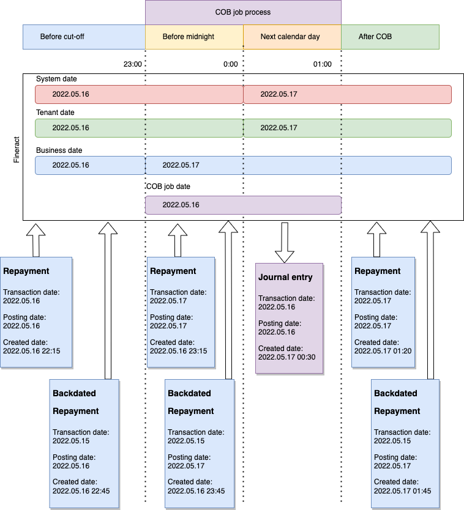

##### Design

It is a logical date which makes it possible to separate the business day from the physical calendar:

- Close a business day before midnight
- Close a business day at midnight
- Close a business day after midnight

Closing a Business Day could be a longer process (see COB jobs) meanwhile some processes shall still be able to create transactions for that business day (COB jobs), but others are meant to create the transactions for the next (incoming transactions): Business date concept is there to sort that out.

Business date concept is essential when:

- Having COB jobs:
  - When the COB was triggered:
    - All the jobs which processing the data must still accounted for actual business day
    - All the incoming transactions must be accounted to the next business day
- Business day is ending before / after midnight (tenant date / system date)
- Testing purposes:
  - Since the transactions and job execution is not tied anymore to a physical calendar, we can easily test a whole loan lifecycle by altering the business date
- Handling disruption of service: For any unseen reason the system goes down or there are any disruption in the workflow, the “missed days” can easily be processed one by one as nothing happened
  - There is a disruption at 2022-06-02
  - The issue is fixed by 2022-06-05
  - The COB flow can be executed for 2022-06-03 and when it is finished for 2022-06-04 and after when the time arrives for 2022-06-05

This logical date is manageable via:

- Job
- API

To maintain such separation from physical calendar we need to introduce the following new dates:

- Business date
- COB date
  - Can be calculated based on the actual business date
    - Depend on COB date strategy (see below)

##### Business date

The - logical - date of the actual business day, eg: 2022-05-06

- It does not support time parts
- It can be managed manually (via API call) or automatically (via scheduled job)
- All business actions during the business day shall use this date:
  - Posting / submitted on date of transactions
  - Submitted on date of actions
  - (Regular) jobs
- It will be used in every situation where the transaction date / value date is not provided by the user or the user provided date shall be validated.
  - Opening date
  - Closing date
  - Disbursal date
  - Transaction/Value date
  - Posting/Submitted date
  - Reversal date
- Will not be use for audit purposes:
  - Created on date
  - Updated on date

##### COB date

The - logical - date of the business day for job execution, eg: 2022-05-05

- It can be calculated based on the business date
  - COB date = business date - 1 day
  - Automatically modified alongside with the business date change
- It does not support time parts
- It is automatically managed by business date change
  - Configurable
- It is used only via COB job execution
  - When we create / modify any business data during the COB job execution, the COB date is to be used:
    - Posting date of transactions
    - Submitted on date of actions
    - Transaction / value date of any actions

##### Some basic example

###### Apply for a loan

#1

Tenant date: 2022-05-23 14:22:12

Business date: 2022-05-22

Submitted on date: 2022-05-23

Outcome: **FAIL**

Message: **The date on which a loan is submitted cannot be in the future.**

Reason: Even the tenant date is 2022-05-23, but the business date was 2022-05-22 which means anything further that date must be considered as a future date.

#2

Tenant date: 2022-05-23 14:22:12

Business date: 2022-05-22

Submitted on date: 2022-05-22

Outcome: **SUCCESS**

Loan application details:

- Submitted on date: 2022-05-22

###### Repayment for a loan

#1

Tenant date: 2022-05-25 11:22:12

Business date: 2022-05-24

Transaction date: 2022-05-25

Outcome: **FAIL**

Message: **The transaction date cannot be in the future.**

Reason: Even the physical date is 2022-05-25, but the business date was 2022-05-24 which means anything further that date must be considered as a future date.

#2

Tenant date: 2022-05-25 11:22:12

Business date: 2022-05-24

Transaction date: 2022-05-23

Outcome: **SUCCESS**

Loan transaction details:

- Submitted on date: 2022-05-24
- Transaction date: 2022-05-23
- Created on date: 2022-05-25 11:22:12

#### Changes in Fineract

We shall modify at all the relevant places where the tenant date was used:

- With very limited exceptions all places where the tenant date is used we need to modify to use the business date.
- Replace system date with tenant date or business date (exceptions may apply)
- Add missing Value dates and Posting dates to entities
- Having a generic naming conventions for JPA fields and DB fields
- Renaming the fields accordingly
- Evaluate value date (transaction date) and posting date (submitted on date), created on date usages
- Jobs to be checked and modified accordingly
- Native queries to be checked and modified accordingly
- Reports to be checked and modified accordingly
- Every table where update is supported the AbstractAuditableCustom should be implemented
- Amend Transactions and Journal entries date handling to fit for business date concept
- For audit fields we shall introduce timezoned datetimes and store them in database accordingly
  - Storing DATETIME fields without Timezone is potential problem due to the daylight savings
  - Also, some external libs (like Quartz) are using system timezone and Fineract will using Tenant timezone for audit fields. To be able to distinct them in DB we shall use DATETIME with TIMESTAMP column types and use timezoned java time objects in the application

### Reliable event framework

Fineract is capable of generating and raising events for external consumers in a reliable way. This section is going to describe all the details on that front with examples.

#### Framework capabilities

##### ACID (transactional) guarantee

The event framework must support ACID guarantees on the business operation level.

Let’s see a simple use-case:

1. A client applies to a loan on the UI
2. The loan is created on the server
3. A loan creation event is raised

What happens if step 3 fails? Shall it fail the original loan creation process?

What happens if step 2 fails but step 3 still gets executed? We’re raising an event for a loan that hasn’t been created in reality.

Therefore, raising an event is tied to the original business transaction to ensure the data that’s getting written into the database along with the respective events are saved in an all-or-nothing fashion.

##### Messaging integration

The system is able to send the raised events to downstream message channels. The current implementation supports the following message channels:

- ActiveMQ

##### Ordering guarantee

The events that are raised will be sent to the downstream message channels in the same order as they were raised.

##### Delivery guarantee

The framework supports the at-least-once delivery guarantee for the raised events.

##### Reliability and fault-tolerance

In terms of reliability and fault-tolerance, the event framework is able to handle the cases when the downstream message channel is not able to accept events. As soon as the message channel is back to operational, the events will be sent again.

##### Selective event producing

Whether or not an event must be sent to downstream message channels for a particular Fineract instance is configurable through the UI and API.

##### Standardized format

All the events sent to downstream message channels are conforming a standardized format using Avro schemas.

##### Extendability and customizations

The event framework is capable of being easily extended with new events for additional business operations or customizing existing events.

##### Ability to send events in bulk

The event framework makes it possible to sort of queue events until they are ready to be sent and send them as a single message instead of sending each event as a separate, individual one.

For example during the COB process, there might be events raised in separate business steps which needs to be sent out but they only need to be sent out at the end of the COB execution process instead of one-by-one.

#### Architecture

##### Intro

On a high-level, the concept looks the following. An event gets raised in a business operation. The event data gets saved to the database - to ensure ACID guarantees. An asynchronous process takes the saved events from the database and puts them onto a message channel.

The flow can be seen in the following diagram:

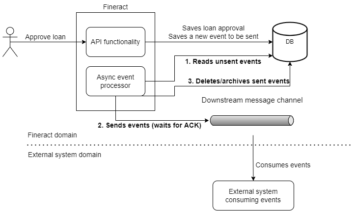

##### Foundational business events

The whole framework is built upon an existing infrastructure in Fineract; the Business Events.

As a quick recap, Business Events are Fineract events that can be raised at any place in a business operation using the `BusinessEventNotifierService`. Callbacks can be registered when a certain type of Business Event is raised and other business operations can be done. For example when a Loan gets disbursed, there’s an interested party doing the Loan Arrears Aging recalculation using the Business Event communication.

The nice thing about the Business Events is that they are tied to the original transaction which means if any of the processing on the subscriber’s side fail, the entire original transaction will be rolled back. This was one of the requirements for the Reliable event framework.

##### Event database integration

The database plays a crucial part in the framework since to ensure transactionality, - without doing proper transaction synchronization between different message channels and the database - the framework is going to save all the raised events into the same relational database that Fineract is using.

###### Database structure

The database structure looks the following

| **Name** | **Type** | **Description** | **Example** |
| --- | --- | --- | --- |
| `id` | number | Auto incremented ID. Not null. | `1` |
| `type` | text | The event type as a string. Not null. | `LoanApprovedBusinessEvent` |
| `schema` | text | The fully qualified name of the schema that was used for the data serialization, as a string. Not null. | `org.apache.fineract.avro.loan.v1.LoanAccountDataV1` |
| `data` | BLOB (MySQL/MariaDB), BYTEA (PostgreSQL) | The event payload as Avro binary. Not null. |  |
| `created_at` | timestamp | UTC timestamp when the event was raised. Not null. | `2022-09-06 14:20:10.148627 +00:00` |
| `status` | text | Enum text representing the status of the external event. Not null, indexed. | `TO_BE_SENT`, `SENT` |
| `sent_at` | timestamp | UTC timestamp when the event was sent. | `2022-09-06 14:30:10.148627 +00:00` |
| `idempotency_key` | text | Randomly generated UUID upon inserting a row into the table for idempotency purposes. Not null. | `68aed085-8235-4722-b27d-b38674c19445` |
| `business_date` | date | The business date to when the event was generated. Not null, indexed. | `2022-09-05` |

The above database table contains the unsent events which later on will be sent by an asynchronous event processor.

Upon successfully sending an event, the corresponding statuses will be updated.

##### Avro schemas

For serializing events, Fineract is using Apache Avro. There are 2 reasons for that:

- More compact storage since Avro is a binary format
- The Avro schemas are published with Fineract as a separate JAR so event consumers can directly map the events into POJOs

There are 3 different levels of Avro schemas used in Fineract for the Reliable event framework which are described below.

###### Standard event schema

The standard event schema is for the regular events. These schemas are used when saving a raised event into the database and using the Avro schema to serialize the event data into a binary format.

For example the OfficeDataV1 Avro schema looks the following:

**`OfficeDataV1.avsc`**

```
{
    "name": "OfficeDataV1",
    "namespace": "org.apache.fineract.avro.office.v1",
    "type": "record",
    "fields": [
        {
            "default": null,
            "name": "id",
            "type": [
                "null",
                "long"
            ]
        },
        {
            "default": null,
            "name": "name",
            "type": [
                "null",
                "string"
            ]
        },
        {
            "default": null,
            "name": "nameDecorated",
            "type": [
                "null",
                "string"
            ]
        },
        {
            "default": null,
            "name": "externalId",
            "type": [
                "null",
                "string"
            ]
        },
        {
            "default": null,
            "name": "openingDate",
            "type": [
                "null",
                "string"
            ]
        },
        {
            "default": null,
            "name": "hierarchy",
            "type": [
                "null",
                "string"
            ]
        },
        {
            "default": null,
            "name": "parentId",
            "type": [
                "null",
                "long"
            ]
        },
        {
            "default": null,
            "name": "parentName",
            "type": [
                "null",
                "string"
            ]
        },
        {
            "default": null,
            "name": "allowedParents",
            "type": [
                "null",
                {
                    "type": "array",
                    "items": "org.apache.fineract.avro.office.v1.OfficeDataV1"
                }
            ]
        }
    ]
}
```

###### Event message schema

The event message schema is just a wrapper around the standard event schema with extra metadata for the event consumers.

Since Avro is strongly typed, the event content needs to be first serialized into a byte sequence and that needs to be wrapped around.

This implies that for putting a single event message onto a message queue for external consumption, data needs to be serialized 2 times; this is the 2-level serialization.

1. Serializing the event
2. Serializing the already serialized event into an event message using the message wrapper

The message schema looks the following:

`MessageV1.avsc`

```
{
    "name": "MessageV1",
    "namespace": "org.apache.fineract.avro",
    "type": "record",
    "fields": [
        {
            "name": "id",
            "doc": "The ID of the message to be sent",
            "type": "long"
        },
        {
            "name": "source",
            "doc": "A unique identifier of the source service",
            "type": "string"
        },
        {
            "name": "type",
            "doc": "The type of event the payload refers to. For example LoanApprovedBusinessEvent",
            "type": "string"
        },
        {
            "name": "category",
            "doc": "The category of event the payload refers to. For example LOAN",
            "type": "string"
        },
        {
            "name": "createdAt",
            "doc": "The UTC time of when the event has been raised; in ISO_LOCAL_DATE_TIME format. For example 2011-12-03T10:15:30",
            "type": "string"
        },
        {
            "name": "businessDate",
            "doc": "The business date when the event has been raised; in ISO_LOCAL_DATE format. For example 2011-12-03",
            "type": "string"
        },
        {
            "name": "tenantId",
            "doc": "The tenantId that the event has been sent from. For example default",
            "type": "string"
        },
        {
            "name": "idempotencyKey",
            "doc": "The idempotency key for this particular event for consumer de-duplication",
            "type": "string"
        },
        {
            "name": "dataschema",
            "doc": "The fully qualified name of the schema of the event payload. For example org.apache.fineract.avro.loan.v1.LoanAccountDataV1",
            "type": "string"
        },
        {
            "name": "data",
            "doc": "The payload data serialized into Avro bytes",
            "type": "bytes"
        }
    ]
}
```

###### Bulk event schema

The bulk event schema is used when multiple events are supposed to be sent together. This schema is used also when serializing the data for the database storing but the idea is quite simple. Have an array of other event schemas embedded into it.

Since Avro is strongly typed, the array within the bulk event schema is an array of `MessageV1` schemas. That way the consumers can decide which events they want to deserialize and which don’t.

This elevates the regular 2-level serialization/deserialization concept up to a 3-level one:

1. Serializing the standard events
2. Serializing the standard events into a bulk event
3. Serializing the bulk event into an event message

###### Versioning

Avro is quite strict with changes to an existing schema and there are a number of compatibility modes available.

Fineract keeps it simple though. Version numbers - in the package names and in the schema names - are increased with each published modification; meaning that if the OfficeDataV1 schema needs a new field and the `OfficeDataV1` schema has been published officially with Fineract, a new `OfficeDataV2` has to be created with the new field instead of modifying the existing schema.

This pattern ensures that a certain event is always deserialized with the appropriate schema definition, otherwise the deserialization could fail.

###### Code generation

The Avro schemas are described as JSON documents. That’s hardly usable directly with Java hence Fineract generates Java POJOs from the Avro schemas. The good thing about these POJOs is the fact that they can be serialized/deserialized in themselves without any magic since they have a `toByteBuffer` and `fromByteBuffer` method.

From POJO to ByteBuffer:

```
LoanAccountDataV1 avroDto = ...
ByteBuffer buffer = avroDto.toByteBuffer();
```

From ByteBuffer to POJO:

```
ByteBuffer buffer = ...
LoanAccountDataV1 avroDto = LoanAccountDataV1.fromByteBuffer(buffer);
```

|  | The ByteBuffer is a stateful container and needs to be handled carefully. Therefore Fineract has a built-in ByteBuffer to byte array converter; `ByteBufferConverter`. |
| --- | --- |

###### Downstream event consumption

When consuming events on the other side of the message channel, it’s critical to know which events the system is interested in. With the multi-level serialization, it’s possible to deserialize only parts of the message and decide based on that whether it makes sense for a particular system to deserialize the event payload more.

Whether events are important can be decided based on:

- the `type` attribute in the message
- the `category` attribute in the message
- the `dataschema` attribute in the message

These are the main attributes in the message wrapper one can use to decide whether an event message is useful.

If the event needs to be deserialized, the next step is to find the corresponding schema definition. That’s going to be sent in the `dataschema` attribute within the message wrapper. Since the attribute contains the fully-qualified name of the respective schema, it can be easily resolved to a Class object. Based on that class, the payload data can be easily deserialized using the `fromByteBuffer` method on every generated schema POJO.

##### Message ordering

One of the requirements for the framework is to provide ordering guarantees. All the events have to conform a happens-before relation.

For the downstream consumers, this can be verified by the `id` attribute within the messages. Since it’s going to be a strictly-monotonic numeric sequence, it can be used for ordering purposes.

##### Event categorization

For easier consumption, the terminology event category is introduced. This is nothing else but the bounded context an event is related to.

For example the LoanApprovedBusinessEvent and the LoanWaiveInterestBusinessEvent are both related to the Loan bounded contexts.

The category in which an event resides in is included in the message under the `category` attribute.

The existing event categories can be found under the Event categories section.

##### Asynchronous event processor

The events stored in the database will be picked up and sent by a regularly executed job.

This job is a Fineract job, scheduled to run for every minute and will pick a number of events in order. Those events will be put onto the downstream message channel in the same order as they were raised.

##### Purging events

The events database table is going to grow continuously. That’s why Fineract has a purging functionality in place that’s gonna delete old and already sent events.

It’s implemented as a Fineract job and is disabled by default. It’s called TBD.

#### Usage

Using the event framework is quite simple. First, it has to be enabled through properties or environment variable.

The respective options are the following:

- the `fineract.events.external.enabled` property
- the `FINERACT_EXTERNAL_EVENTS_ENABLED` environment variable

These configurations accept a boolean value; `true` or `false`.

The key component to interact with is the `BusinessEventNotifierService#notifyPostBusinessEvent` method.

##### Raising events

Raising events is really easy. An instance of a BusinessEvent interface is needed, that’s going to be the event. There are plenty of them available already in the Fineract codebase.

And that’s pretty much it. Everything else is taken care of in terms of event data persisting and later on putting it onto a message channel.

An example of event raising:

```
@Override
public CommandProcessingResult createClient(final JsonCommand command) {
    ...
    businessEventNotifierService.notifyPostBusinessEvent(new ClientCreateBusinessEvent(newClient));
    ...
    return ...;
}
```

|  | The above code is copied from the `ClientWritePlatformServiceJpaRepositoryImpl` class. |
| --- | --- |

###### Example event message content

Since the message is serialized into binary format, it’s hard to represent in the documentation therefore here’s a JSON representation of the data, just as an example.

```
{
    "id": 121,
    "source": "a65d759d-04f9-4ddf-ac52-34fa5d1f5a25",
    "type": "LoanApprovedBusinessEvent",
    "category": "Loan",
    "createdAt": "2022-09-05T10:15:30",
    "tenantId": "default",
    "idempotencyKey": "abda146d-68b5-48ca-b527-16d2b7c5daef",
    "dataschema": "org.apache.fineract.avro.loan.v1.LoanAccountDataV1",
    "data": "..."
}
```

|  | The source attribute refers to an ID that’s identifying the producer service. Fineract will regenerate this ID upon each application startup. |
| --- | --- |

##### Raising bulk events

Raising bulk events is really easy as well. The 2 key methods are:

- `BusinessEventNotifierService#startExternalEventRecording`
- `BusinessEventNotifierService#stopExternalEventRecording`

First, you have to start recording your events. This recording will be applied for the current thread. And then you can raise as many events as you want with the regular `BusinessEventNotifierService#notifyPostBusinessEvent` method, but they won’t get saved to the database immediately. They’ll get "recorded" into an internal buffer.

When you stop recording using the method above, all the recorded events will be saved as a bulk event to the database; and serialized appropriately.

From then on, the bulk event works just like any of the event. It’ll be picked up by the processor to send it to a message channel.

##### Bulk events on reverse-replay

When a backdated transaction, a reversal or another change makes Fineract re-process the later transactions of a loan or a working capital loan, the adjustments it causes reach the consumer together, also when one command both reverses a transaction and books its replacement with a new amount. If there is nothing to report, nothing is sent. A single adjustment is sent as a regular `LoanAdjustTransactionBusinessEvent` or `WorkingCapitalLoanAdjustTransactionBusinessEvent`. Two or more are sent as one `BulkBusinessEvent` with one adjust event per transaction, in replay order. If a bulk event is already being recorded higher up, for example by a COB run with bulk events enabled, the adjustments join it.

A charge-off that the re-processing reverses because nothing is left to charge off is one of the replayed transactions: its reversal is reported inside the bulk event like any other replayed transaction, and the lifted charge-off is additionally announced by a separate `WorkingCapitalLoanUndoChargeOffBusinessEvent`. The event of the operation that triggered the re-processing, such as the reversal of the transaction the user reversed, the event of the new backdated transaction or the adjust event that pairs an adjusted transaction with its replacement, is posted separately, and so are the discount fee amortization adjustments of a working capital loan.

A charge added to an overpaid loan is paid out of the overpayment of earlier repayments. A loan re-processes its transactions for that; a working capital loan moves the amount from the overpayment portion of those repayments to their fee or penalty portion in place, oldest repayment first. Either way, every repayment whose split changes is reported under the same rules, and the event of the added charge is posted separately.

The payload differs between the two loan types. A loan replaces each replayed transaction: `transactionToAdjust` is the reversed original and `newTransactionDetail` is the new transaction, with a new id, or empty when the replay only reverses the transaction. A working capital loan updates the allocation in place and reports only the transactions whose split changed: `transactionToAdjust` and `newTransactionDetail` hold the state of the same transaction id before and after the re-processing. A working capital transaction that the re-processing reverses is reported like any other working capital reversal: `transactionToAdjust` is the reversed transaction and `newTransactionDetail` is empty.

##### Event categories

TBD

##### Selective event producing

Every event type has a row in the `m_external_event_configuration` table with an `enabled` flag, maintained through the `/externalevents/configuration` API. A disabled event type is still raised internally (its listeners run as usual) but no external event is created for it, neither on its own nor as an item of a bulk event.

Some events are derived from a transaction of another type: the transaction adjustment events (`LoanAdjustTransactionBusinessEvent`, `WorkingCapitalLoanAdjustTransactionBusinessEvent`) are one event type regardless of which transaction got adjusted. Such an event implements `DependentExternalEvent` and names the event type of the adjusted transaction type (for example `LoanReAgeTransactionBusinessEvent` for a re-age); it’s only posted externally when both its own type and that governing type are enabled. Disabling a transaction type’s event therefore also silences the adjustments of that transaction type, including the ones raised by a reverse-replay. Transaction types without an event of their own are governed by the adjustment event alone.

#### Customizations

The framework provides a number of customization options:

- Creating new events (that’s already given by the Business Events)
- Creating new Avro schemas
- Customizing what data gets serialized for existing events

In the upcoming sections, that’s what going to be discussed.

##### Creating new events

Creating new events is super easy. Just create an implementation of the `BusinessEvent` interface and that’s it.

From then on, you can raise those events in the system, although you can’t publish them to an external message channel. If you have the event framework enabled, it’s going to fail with not finding the appropriate serializer for your business event.

[output not shown]

The interface looks the following:

`BusinessEvent.java`

```
public interface BusinessEvent<T> {

    T get();

    String getType();

    String getCategory();

    Long getAggregateRootId();
}
```

Quite simple. The `get` method should return the data you want to pass within the event instance. The `getType` method returns the name of the business event that’s gonna be saved as the `type` into the database.

[output not shown]

##### Creating new Avro schemas and serializers

First let’s talk about the event serializers because that’s what’s needed to make a new event compatible with the framework.

The serializer has a special interface, `BusinessEventSerializer`.

`BusinessEventSerializer.java`

```
public interface BusinessEventSerializer {

    <T> boolean canSerialize(BusinessEvent<T> event);

    Class<? extends GenericContainer> getSupportedSchema();

    <T> ByteBufferSerializable toAvroDTO(BusinessEvent<T> rawEvent);

}
```

An implementation of this interface shall be registered as a Spring bean, and it’ll be picked up automatically by the framework.

|  | You can look at the existing serializers for implementation ideas. |
| --- | --- |

New Avro schemas can be easily created. Just create a new Avro schema file in the `fineract-avro-schemas` project under the respective bounded context folder, and it will be picked up automatically by the code generator.

##### BigDecimal support in Avro schemas

Apache Avro by default doesn’t support complex types like a BigDecimal. It has to be implemented using a custom snippet like this:

```
{
    "logicalType": "decimal",
    "precision": 27,
    "scale": 8,
    "type": "bytes"
}
```

Obviously it’s quite challenging to copy-paste this snippet to every single BigDecimal field, so there’s a customization in place for Fineract.  
The type `bigdecimal` is supported natively, and you’re free to use it like this:

```
{
    "default": null,
    "name": "principal",
    "type": [
        "null",
        "bigdecimal"
    ]
}
```

|  | This `bigdecimal` type will be simple replaced with the BigDecimal snippet showed above during the compilation process. |
| --- | --- |

##### Custom data serialization for existing events

In case there’s a need some extra bit of information within the event message that the default serializers are not providing, you can override this behavior by registering a brand-new custom serializer (as shown above).

Since there’s a priority order of serializers, the only thing the custom serializer need to do is to be annotated by the `@Order` annotation or to implement the `Ordered` interface.

An example custom serializer with priority looks the following:

```
@Component
@RequiredArgsConstructor
@Order(Ordered.HIGHEST_PRECEDENCE)
public class CustomLoanBusinessEventSerializer implements BusinessEventSerializer {
    ...

    @Override
    public <T> boolean canSerialize(BusinessEvent<T> event) {
        return ...;
    }

    @Override
    public <T> byte[] serialize(BusinessEvent<T> rawEvent) throws IOException {
        ...
        ByteBuffer buffer = avroDto.toByteBuffer();
        return byteBufferConverter.convert(buffer);
    }

    @Override
    public Class<? extends GenericContainer> getSupportedSchema() {
        return ...;
    }
}
```

|  | All the default serializers are having `Ordered.LOWEST_PRECEDENCE`. |
| --- | --- |

#### Appendix A: Properties and environment variables

| Property name | Environment variable | Default value | Description |
| --- | --- | --- | --- |
| `fineract.events.external.enabled` | `FINERACT_EXTERNAL_EVENTS_ENABLED` | `false` | Whether the external event sending is enabled or disabled. |

### Introducing Advanced payment allocation

Since the first repayment strategy got introduced, many followed, but there was one thing common in them:

- They were hard coding the allocation rules for each transaction type.

By introducing the "Advanced payment allocation" the idea was to have a repayment strategy which was:

- supporting dynamic configuration of the allocation rules for transaction types
- supporting configuration of more fine-grained allocation rules for future installments
- supporting reprocessing of transactions and charges in chronological order

#### Glossary

| *Advanced payment allocation | Ability to configure allocation rules dynamically for transactions |
| --- | --- |
| *Payment allocation | Rule that defines which outstanding balance to be paid of first on which installment |
| *Re-amortization | Transaction amount to be divided into equal portions by the number of future installments and those installments to be paid by these portions. |

#### Capabilities

- Payment allocation should be configurable for transactions:
  - Repayment
  - Goodwill credit
  - Payout refund
  - Merchant refund
  - Charge adjustments
  - etc.
- Can be configured for Loan products
  - Payment allocation rule changes on the loan product will affect only the newly created Loan accounts.
- Chronological reprocess order
  - Transactions (including disbursements) and charges are (re)processed and allocated in chronological order
- Support re-amortization between future installments
  - Transaction amount to be divided into equal portions (based on the number of future installments) and to repay each future installment by the calculated portion.
    - It’s not hard coded, but usually the principal portion needs to be allocated first, but if there are still unprocessed amounts, the rest of the outstanding balances are to be allocated based on the rest of the rules
- Main allocation rules (installment level)
  - Past Due Installment(s):
    - Oldest first
  - Due Installment(s):
    - Normal installment takes priority over Down-payment installment (if applicable)
  - Future Installment(s):
    - Available allocation orders:
      - Next installment first
      - Last installment first
      - Re-amortization*
- Secondary allocation rules
  - Penalty
  - Fee
  - Interest
  - Principal

#### Configuration

Advanced repayment allocation rules can be configured for the Loan product if "Advanced payment allocation" got selected as repayment strategy.

There will be a (always required) “DEFAULT” transaction type configuration which acts as fallback ruleset, if the there are no configured rules for a specific transaction type.

##### New repayment strategy

- Name: Advanced payment allocation
- Code: advanced-payment-allocation-strategy
- Order: 8

##### Allocation rules

- Past due penalty
- Past due fee
- Past due principal
- Past due interest
- Due penalty
- Due fee
- Due principal
- Due interest
- In advance penalty
- In advance fee
- In advance principal
- In advance interest

###### Future installment allocation rules:

- Next installment
- Last installment
- Re-amortization

##### Example Request

[output not shown]

The above request configures the "DEFAULT" allocation rules:

- First the already due penalties to be paid
- Second the already due fees to be paid
- Last the future interests to be paid

Also for future installments set the allocation rules as

- First future installment by due date to be paid first

##### High level design

Flow of advanced payment allocation processing

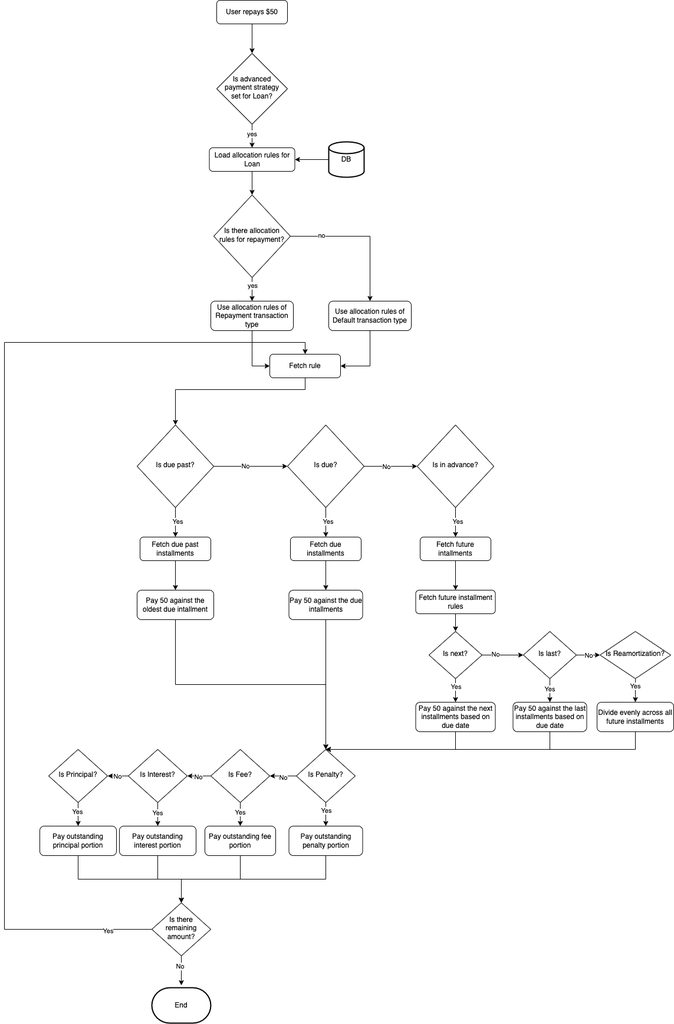

### API Backward Compatibility

#### Overview

Apache Fineract enforces API backward compatibility using swagger-brake, an automated tool that compares OpenAPI specifications between the base branch and a pull request to detect breaking changes. This ensures that existing API consumers are not broken when new changes are deployed.

The check runs automatically on every pull request via the `verify-api-backward-compatibility.yml` GitHub Actions workflow.

#### How It Works

The workflow follows these steps:

1. **Generate baseline spec** — Checks out the base branch (e.g. `develop`) and runs `./gradlew :fineract-provider:resolve` to generate the current OpenAPI specification.
2. **Generate PR spec** — Checks out the PR branch and generates its OpenAPI specification.
3. **Sanitize specs** — Patches known issues in the generated specs (e.g. missing `schema` entries in `requestBody` content) to prevent false positives.
4. **Compare** — Runs `checkBreakingChanges` via the swagger-brake Gradle plugin to compare old vs new specs.
5. **Report** — If breaking changes are found:
   - A deduplicated summary table is written to the GitHub Actions Step Summary (visible on the workflow run page).
   - A comment is posted on the PR (when token permissions allow).
   - The full JSON report is archived as a build artifact.
   - The workflow **fails**, blocking the PR.

#### Breaking Change Rules

swagger-brake detects the following categories of breaking changes:

##### Endpoint Rules

| Rule | Description |
| --- | --- |
| R001 | A stable (non-beta) API was changed to beta |
| R002 | An API path was deleted |

##### Request Rules

| Rule | Description |
| --- | --- |
| R003 | A request media type (content type) was removed |
| R004 | A request parameter was deleted |
| R005 | An enum value was removed from a request parameter |
| R006 | A parameter location changed (e.g. `query` to `header`) |
| R007 | A parameter was made required |
| R008 | A parameter type was changed |
| R009 | An attribute was removed from a request body schema |
| R010 | A property type was changed in a request schema |
| R011 | An enum value was removed from a request body schema |

##### Response Rules

| Rule | Description |
| --- | --- |
| R012 | A response code was deleted |
| R013 | A response media type was removed |
| R014 | An attribute was removed from a response schema |
| R015 | A property type was changed in a response schema |
| R016 | An enum value was removed from a response schema |

##### Constraint Rules

| Rule | Description |
| --- | --- |
| R017 | A request parameter constraint was tightened (covers `maxLength`, `minLength`, `maximum`, `minimum`, `maxItems`, `minItems`, `uniqueItems`) |

#### Gradle Configuration

The swagger-brake plugin is configured in `fineract-provider/build.gradle`:

```
apply plugin: 'com.docktape.swagger-brake'

swaggerBrake {
    newApi = "${project.buildDir}/resources/main/static/fineract.json"
    oldApi = findProperty('apiBaseline') ?: "${projectDir}/config/swagger/fineract-baseline.json"
    outputFormats = ['JSON']
    outputFilePath = "${project.buildDir}/swagger-brake"
    deprecatedApiDeletionAllowed = true
    strictValidation = false
}
```

##### Configuration Options

| Option | Default | Description |
| --- | --- | --- |
| `newApi` | — | Path to the new (PR branch) OpenAPI spec. Generated by the `resolve` task. |
| `oldApi` | — | Path to the baseline OpenAPI spec. Provided via `-PapiBaseline` in CI, or falls back to a local file. |
| `outputFormats` | `['STDOUT', 'HTML']` | Report formats. We use `['JSON']` to avoid STDOUT spam and parse the report programmatically. |
| `outputFilePath` | `build/swagger-brake` | Directory for generated reports. |
| `deprecatedApiDeletionAllowed` | `true` | When `true`, removing a deprecated endpoint is NOT a breaking change. |
| `strictValidation` | `true` | When `false`, schemas without an explicit `type` field log a warning instead of failing. Set to `false` for Fineract because the generated spec has many type-less schemas. |
| `excludedPaths` | `[]` | List of path prefixes to skip (e.g. `['/v1/smscampaigns', '/v1/internal']`). Useful for excluding endpoints undergoing cleanup. |
| `ignoredBreakingChangeRules` | `[]` | List of rule codes to suppress entirely (e.g. `['R001']`). |
| `betaApiExtensionName` | `x-beta-api` | Vendor extension name for marking beta APIs. Beta endpoints can be freely modified without triggering violations. |
| `maxLogSerializationDepth` | `3` | Controls nested object serialization depth in logs (range 1-20). Increase if you see `StackOverflowError` from circular schema references. |

#### Running Locally

To run the check locally, you need a baseline spec to compare against:

```
# 1. Generate the baseline from develop
git stash
git switch develop
./gradlew :fineract-provider:resolve --no-daemon
cp fineract-provider/build/resources/main/static/fineract.json /tmp/baseline.json
git switch -
git stash pop

# 2. Generate your current spec and compare
./gradlew :fineract-provider:checkBreakingChanges \
  -PapiBaseline="/tmp/baseline.json" \
  --no-daemon
```

The JSON report is written to `fineract-provider/build/swagger-brake/`.

#### Handling Breaking Changes

##### Intentional Breaking Changes

If your PR intentionally introduces a breaking API change (e.g. removing a deprecated field):

1. The workflow will fail and report the violations.
2. Document the breaking change in the PR description with justification.
3. A committer will review and approve the PR with the understanding that the API contract is changing.

##### Excluding Paths Under Cleanup

If you need to fix incorrect API annotations on endpoints that are not yet stable, use `excludedPaths` to temporarily exclude them from checking:

```
swaggerBrake {
    excludedPaths = [
        '/v1/smscampaigns',
        '/v1/email',
    ]
}
```

Path exclusion is **prefix-based** — excluding `/v1/smscampaigns` will skip all paths starting with that prefix.

Remove the exclusion once the cleanup is complete.

##### Marking Endpoints as Beta

For endpoints that are experimental or under active development, mark them as beta in the Java code:

```
@Operation(
    summary = "...",
    extensions = @Extension(
        properties = @ExtensionProperty(name = "x-beta-api", value = "true")
    )
)
```

Beta endpoints can be freely modified, created, or removed without triggering violations. Promoting a beta endpoint to stable (removing the extension) is also non-breaking. However, demoting a stable endpoint to beta **is** a breaking change (R001).

#### Report Format

When breaking changes are detected, the workflow produces a deduplicated summary table:

| Rule | Description | Detail | Affected endpoints | Count |
| --- | --- | --- | --- | --- |
| R014 | Response attribute removed | `totalOverpaid` | `GET /v1/loans`, `GET /v1/loans/{loanId}`, `GET /v1/loans/external-id/{loanExternalId}` | 3 |

The deduplication groups violations by rule code and affected attribute, collapsing multiple endpoint occurrences into a single row. This is important because a single schema change (e.g. removing a field from a shared response type) can generate dozens of raw violations — one per endpoint that uses that schema.

#### Tool Reference

- **Tool**: swagger-brake v2.7.0
- **Gradle plugin**: `com.docktape.swagger-brake`
- **Documentation**: docktape.github.io/swagger-brake/
- **License**: Apache 2.0

## Command Processing

|  | This is an ongoing effort to migrate to an improved [CQRS](https://martinfowler.com/bliki/CQRS.html[CQRS]) sub-system. Please read Jira ticket FINERACT-2169 to see the current progress. |
| --- | --- |

### Introduction

Fineract accumulated some technical debt over the years. One area that is implicated is type-safety of internal and external facing APIs, the most prominent of which is Fineract’s REST API. In general the package layout of the project reflects a more or less classic layered architecture (REST API, data transfer/value objects, business logic services, storage/repositories). The project predates some of the more modern frameworks and best practices that are available today and on occasions the data structures that are exchanged offer some challenges (e.g. generic types). Fineract’s code base reflects that, especially where JSON de-/serialization is involved. Nowadays, this task would be simply delegated to the Jackson framework, but when Fineract (MifosX) started, the decision was made to use Google’s GSON library and create handcrafted helper classes to deal with JSON parsing. While this provided a lot of flexibility the approach had some downsides:

- the lowest common denominator is the string type (aka JSON blob); this is where we lose the type information
- the strings are transformed into JSONObjects; a little bit better than raw strings, but barely more than a hash map
- "magic" strings are needed to get/set values
- this approach makes refactoring more difficult
- to be able to serve an OpenAPI descriptor (as JSON and YAML) we had to re-introduce the type information at the REST API level with dummy classes that contain only the specified attributes; those classes are only used with the Swagger annotations and no were else
- some developers skipped the layered architecture and found it too tedious to maintain DTOs and JSON helper classes, and as a result just passed JSONObjects right to the business logic layer
- now the business logic is unnecessarily aware of how Fineract communicates to the outside world and makes replacing/enhancing the communication protocol (e.g. with GRPC) pretty much impossible

The list doesn’t end here, but in the end things boil down to two main points:

- developer experience: boilerplate code and missing type safety cost more time
- bugs: the more code the more likely errors get introduced, especially when type safety is missing and we have to rely on runtime errors (vs. compile time).

There has been already some preparatory work done concerning type safety, but until now we avoided dealing with the real source of this issue. Fineract’s architectures devises read from write requests ([CQRS](https://martinfowler.com/bliki/CQRS.html)) for improved scalability.

The read requests are not that problematic and not (yet) covered, but all write requests pass through a component/service that is called `SynchronousCommandProcessingService`.

Synchronous Command Processing Service

```
public class SynchronousCommandProcessingService implements CommandProcessingService {

    public static final String IDEMPOTENCY_KEY_STORE_FLAG = "idempotencyKeyStoreFlag";

    public static final String IDEMPOTENCY_KEY_ATTRIBUTE = "IdempotencyKeyAttribute";
    public static final String COMMAND_SOURCE_ID = "commandSourceId";
    private final PlatformSecurityContext context;
    private final ApplicationContext applicationContext;
    private final TransactionBoundApplicationEventPublisher eventPublisher;
    private final ToApiJsonSerializer<Map<String, Object>> toApiJsonSerializer;
    private final ToApiJsonSerializer<CommandProcessingResult> toApiResultJsonSerializer;
    private final ConfigurationDomainService configurationDomainService;
    private final CommandHandlerProvider commandHandlerProvider;
    private final IdempotencyKeyResolver idempotencyKeyResolver;
    private final CommandSourceService commandSourceService;
    private final RetryConfigurationAssembler retryConfigurationAssembler;

    private final FineractRequestContextHolder fineractRequestContextHolder;
    private final Gson gson = GoogleGsonSerializerHelper.createSimpleGson();

    private CommandProcessingResult executeWithRetry(CommandExecutionContext executionContext) {
        try {
            if (!BatchRequestContextHolder.isEnclosingTransaction()) {
                return retryConfigurationAssembler.getRetryConfigurationForExecuteCommand()
                        .executeSupplier(() -> executeCommandAttempt(executionContext));
            }
            return executeCommandAttempt(executionContext);
        } catch (RollbackTransactionNotApprovedException e) {
            throw e;
        } catch (RuntimeException e) {
            RuntimeException mappable = ErrorHandler.getMappable(e);
            persistFinalErrorResult(executionContext, mappable);
            throw mappable;
        }
    }

    @Override
    public CommandProcessingResult executeCommand(final CommandWrapper wrapper, final JsonCommand command,
            final boolean isApprovedByChecker) {
        return executeWithRetry(new CommandExecutionContext(wrapper, command, isApprovedByChecker));
    }

    private CommandProcessingResult executeCommandAttempt(CommandExecutionContext executionContext) {
        // Do not store the idempotency key because of the exception handling
        setIdempotencyKeyStoreFlag(false);

        CommandWrapper wrapper = executionContext.wrapper();
        JsonCommand command = executionContext.command();
        Long commandId = (Long) fineractRequestContextHolder.getAttribute(COMMAND_SOURCE_ID, null);
        boolean isRetry = commandId != null;
        boolean isEnclosingTransaction = BatchRequestContextHolder.isEnclosingTransaction();
        executionContext.setEnclosingTransaction(isEnclosingTransaction);

        CommandSource commandSource = null;
        String idempotencyKey;
        if (isRetry) {
            commandSource = commandSourceService.getCommandSource(commandId);
            idempotencyKey = commandSource.getIdempotencyKey();
        } else if ((commandId = command.commandId()) != null) { // action on the command itself
            commandSource = commandSourceService.getCommandSource(commandId);
            idempotencyKey = commandSource.getIdempotencyKey();
        } else {
            idempotencyKey = idempotencyKeyResolver.resolve(wrapper);
        }
        exceptionWhenTheRequestAlreadyProcessed(wrapper, idempotencyKey, isRetry);

        AppUser user = context.authenticatedUser(wrapper);
        if (commandSource == null) {
            if (isEnclosingTransaction) {
                commandSource = commandSourceService.getInitialCommandSource(wrapper, command, user, idempotencyKey);
            } else {
                commandSource = commandSourceService.saveInitial(wrapper, command, user, idempotencyKey);
                commandId = commandSource.getId();
            }
        }
        executionContext.setCommandSource(commandSource);
        if (commandId != null) {
            storeCommandIdInContext(commandSource); // Store command id as a request attribute
        }

        setIdempotencyKeyStoreFlag(true);

        return executeCommandInTransaction(executionContext, commandSource, user, isEnclosingTransaction);
    }

    private CommandProcessingResult executeCommandInTransaction(CommandExecutionContext executionContext, CommandSource commandSource,
            AppUser user, boolean isEnclosingTransaction) {

        final CommandSourceService.CommandExecutionResult commandExecutionResult;
        try {
            commandExecutionResult = commandSourceService.processCommandAndSaveResult(findCommandHandler(executionContext.wrapper()),
                    executionContext.command(), commandSource, user, executionContext.approvedByChecker(), this::updateSuccessfulResult);
        } catch (RollbackTransactionNotApprovedException e) {
            ErrorInfo errorInfo = commandSourceService.generateErrorInfo(e);
            commandSource.setResultStatusCode(errorInfo.getStatusCode());
            commandSource.setResult(errorInfo.getMessage());
            if (!isEnclosingTransaction) { // TODO: temporary solution
                commandSourceService.saveResult(commandSource);
            }
            publishHookErrorEvent(executionContext.wrapper(), executionContext.command(), errorInfo);
            throw e;
        }

        CommandProcessingResult result = commandExecutionResult.result();
        storeCommandIdInContext(commandExecutionResult.commandSource());

        result.setRollbackTransaction(null);

        // When running inside an enclosing batch transaction, defer hook publication
        // until after the transaction commits. This prevents webhooks from firing for
        // commands that are subsequently rolled back when a later command in the batch
        // fails (e.g. a withdrawal succeeds but its fee charge fails, rolling back both).
        if (isEnclosingTransaction && TransactionSynchronizationManager.isSynchronizationActive()) {
            TransactionSynchronizationManager.registerSynchronization(new TransactionSynchronization() {
```

```
                @Override
                public void afterCommit() {
                    publishHookEvent(executionContext.wrapper().entityName(), executionContext.wrapper().actionName(),
                            executionContext.command(), result);
                }
            });
        } else {
            publishHookEvent(executionContext.wrapper().entityName(), executionContext.wrapper().actionName(), executionContext.command(),
                    result);
        }

        return result;
    }

    private void updateSuccessfulResult(CommandSource commandSource, CommandProcessingResult result) {
        commandSource.setResultStatusCode(SC_OK);
        commandSource.updateForAudit(result);
        commandSource.setResult(toApiResultJsonSerializer.serializeResult(result));
        commandSource.setStatus(PROCESSED);
    }

    private void persistFinalErrorResult(CommandExecutionContext executionContext, RuntimeException mappable) {
        CommandSource commandSource = executionContext.commandSource();
        if (commandSource == null) {
            return;
        }
        ErrorInfo errorInfo = commandSourceService.generateErrorInfo(mappable);
        publishHookErrorEvent(executionContext.wrapper(), executionContext.command(), errorInfo);
        if (executionContext.enclosingTransaction()) {
            return;
        }

        Integer statusCode = errorInfo.getStatusCode();
        commandSource.setResultStatusCode(statusCode);
        commandSource.setResult(errorInfo.getMessage());
        if (statusCode != SC_OK) {
            commandSource.setStatus(ERROR);
        }
        commandSourceService.saveResult(commandSource);
    }

    private void storeCommandIdInContext(CommandSource savedCommandSource) {
        if (savedCommandSource.getId() == null) {
            throw new IllegalStateException("Command source not saved");
        }
        // Idempotency filters and retry need this
        fineractRequestContextHolder.setAttribute(COMMAND_SOURCE_ID, savedCommandSource.getId());
    }

    private void publishHookErrorEvent(CommandWrapper wrapper, JsonCommand command, ErrorInfo errorInfo) {
        try {
            publishHookEvent(wrapper.entityName(), wrapper.actionName(), command, gson.toJson(errorInfo));
        } catch (Exception e) {
            log.error("Failed to publish hook error event for entity: {}, action: {}", wrapper.entityName(), wrapper.actionName(), e);
        }
    }

    private void exceptionWhenTheRequestAlreadyProcessed(CommandWrapper wrapper, String idempotencyKey, boolean retry) {
        CommandSource command = commandSourceService.findCommandSource(wrapper, idempotencyKey);
        if (command == null) {
            return;
        }
        CommandProcessingResultType status = CommandProcessingResultType.fromInt(command.getStatus());
        switch (status) {
            case UNDER_PROCESSING -> {
                Class<?> lastExecutionExceptionClass = retryConfigurationAssembler.getLastException();
                if (lastExecutionExceptionClass == null
                        || IdempotentCommandProcessUnderProcessingException.class.isAssignableFrom(lastExecutionExceptionClass)) {
                    throw new IdempotentCommandProcessUnderProcessingException(wrapper, idempotencyKey);
                }
            }
            case PROCESSED -> throw new IdempotentCommandProcessSucceedException(wrapper, idempotencyKey, command);
            case ERROR -> {
                if (!retry) {
                    throw new IdempotentCommandProcessFailedException(wrapper, idempotencyKey, command);
                }
            }
            default -> {
            }
        }
    }

    private void setIdempotencyKeyStoreFlag(boolean flag) {
        fineractRequestContextHolder.setAttribute(IDEMPOTENCY_KEY_STORE_FLAG, flag);
    }

    private static final class CommandExecutionContext {

        private final CommandWrapper wrapper;
        private final JsonCommand command;
        private final boolean approvedByChecker;
        private CommandSource commandSource;
        private boolean enclosingTransaction;

        private CommandExecutionContext(CommandWrapper wrapper, JsonCommand command, boolean approvedByChecker) {
            this.wrapper = wrapper;
            this.command = command;
            this.approvedByChecker = approvedByChecker;
        }

        CommandWrapper wrapper() {
            return wrapper;
        }

        JsonCommand command() {
            return command;
        }

        boolean approvedByChecker() {
            return approvedByChecker;
        }

        CommandSource commandSource() {
            return commandSource;
        }

        void setCommandSource(CommandSource commandSource) {
            this.commandSource = commandSource;
        }

        boolean enclosingTransaction() {
            return enclosingTransaction;
        }

        void setEnclosingTransaction(boolean enclosingTransaction) {
            this.enclosingTransaction = enclosingTransaction;
        }
    }

    private NewCommandSourceHandler findCommandHandler(final CommandWrapper wrapper) {
        NewCommandSourceHandler handler;

        if (wrapper.isDatatableResource()) {
            if (wrapper.isCreateDatatable()) {
                handler = applicationContext.getBean("createDatatableCommandHandler", NewCommandSourceHandler.class);
            } else if (wrapper.isDeleteDatatable()) {
                handler = applicationContext.getBean("deleteDatatableCommandHandler", NewCommandSourceHandler.class);
            } else if (wrapper.isUpdateDatatable()) {
                handler = applicationContext.getBean("updateDatatableCommandHandler", NewCommandSourceHandler.class);
            } else if (wrapper.isCreate()) {
                handler = applicationContext.getBean("createDatatableEntryCommandHandler", NewCommandSourceHandler.class);
            } else if (wrapper.isUpdateMultiple()) {
                handler = applicationContext.getBean("updateOneToManyDatatableEntryCommandHandler", NewCommandSourceHandler.class);
            } else if (wrapper.isUpdateOneToOne()) {
                handler = applicationContext.getBean("updateOneToOneDatatableEntryCommandHandler", NewCommandSourceHandler.class);
            } else if (wrapper.isDeleteMultiple()) {
                handler = applicationContext.getBean("deleteOneToManyDatatableEntryCommandHandler", NewCommandSourceHandler.class);
            } else if (wrapper.isDeleteOneToOne()) {
                handler = applicationContext.getBean("deleteOneToOneDatatableEntryCommandHandler", NewCommandSourceHandler.class);
            } else if (wrapper.isRegisterDatatable()) {
                handler = applicationContext.getBean("registerDatatableCommandHandler", NewCommandSourceHandler.class);
            } else {
                throw new UnsupportedCommandException(wrapper.commandName());
            }
        } else if (wrapper.isNoteResource()) {
            if (wrapper.isCreate()) {
                handler = applicationContext.getBean("createNoteCommandHandler", NewCommandSourceHandler.class);
            } else if (wrapper.isUpdate()) {
                handler = applicationContext.getBean("updateNoteCommandHandler", NewCommandSourceHandler.class);
            } else if (wrapper.isDelete()) {
                handler = applicationContext.getBean("deleteNoteCommandHandler", NewCommandSourceHandler.class);
            } else {
                throw new UnsupportedCommandException(wrapper.commandName());
            }
        } else if (wrapper.isSurveyResource()) {
            if (wrapper.isRegisterSurvey()) {
                handler = applicationContext.getBean("registerSurveyCommandHandler", NewCommandSourceHandler.class);
            } else if (wrapper.isFullFilSurvey()) {
                handler = applicationContext.getBean("fullFilSurveyCommandHandler", NewCommandSourceHandler.class);
            } else {
                throw new UnsupportedCommandException(wrapper.commandName());
            }
        } else if (wrapper.isLoanDisburseDetailResource()) {
            if (wrapper.isUpdateDisbursementDate()) {
                handler = applicationContext.getBean("updateLoanDisburseDateCommandHandler", NewCommandSourceHandler.class);
            } else if (wrapper.addAndDeleteDisbursementDetails()) {
                handler = applicationContext.getBean("addAndDeleteLoanDisburseDetailsCommandHandler", NewCommandSourceHandler.class);
            } else {
                throw new UnsupportedCommandException(wrapper.commandName());
            }
        } else if (wrapper.isInterestPauseResource()) {
            if (wrapper.isInterestPauseCreateResource()) {
                handler = applicationContext.getBean("createInterestPauseCommandHandler", NewCommandSourceHandler.class);
            } else if (wrapper.isInterestPauseUpdateResource()) {
                handler = applicationContext.getBean("updateInterestPauseCommandHandler", NewCommandSourceHandler.class);
            } else if (wrapper.isInterestPauseDeleteResource()) {
                handler = applicationContext.getBean("deleteInterestPauseCommandHandler", NewCommandSourceHandler.class);
            } else {
                throw new UnsupportedCommandException(wrapper.commandName());
            }
        } else {
            handler = commandHandlerProvider.getHandler(wrapper.entityName(), wrapper.actionName());
        }
```

```
        return handler;
    }

    @Override
    public boolean validateRollbackCommand(final CommandWrapper commandWrapper, final AppUser user) {
        user.validateHasPermissionTo(commandWrapper.getTaskPermissionName());
        boolean isMakerChecker = configurationDomainService.isMakerCheckerEnabledForTask(commandWrapper.taskPermissionName());
        return isMakerChecker && !user.isCheckerSuperUser();
    }

    protected void publishHookEvent(final String entityName, final String actionName, JsonCommand command, final Object result) {
        try {
            final AppUser appUser = context.authenticatedUser(CommandWrapper.wrap(actionName, entityName, null, null));

            final HookEventSource hookEventSource = new HookEventSource(entityName, actionName);

            // TODO: Add support for publishing array events
            if (command.json() != null) {
                Type type = new TypeToken<Map<String, Object>>() {

                }.getType();

                Map<String, Object> myMap;

                try {
                    myMap = gson.fromJson(command.json(), type);
                } catch (Exception e) {
                    throw new PlatformApiDataValidationException("error.msg.invalid.json", "The provided JSON is invalid.",
                            new ArrayList<>(), e);
                }

                Map<String, Object> reqmap = new HashMap<>();
                reqmap.put("entityName", entityName);
                reqmap.put("actionName", actionName);
                reqmap.put("createdBy", context.authenticatedUser().getId());
                reqmap.put("createdByName", context.authenticatedUser().getUsername());
                reqmap.put("createdByFullName", context.authenticatedUser().getDisplayName());

                reqmap.put("request", myMap);
                if (result instanceof CommandProcessingResult) {
                    CommandProcessingResult resultCopy = CommandProcessingResult
                            .fromCommandProcessingResult((CommandProcessingResult) result);

                    reqmap.put("officeId", resultCopy.getOfficeId());
                    reqmap.put("clientId", resultCopy.getClientId());
                    resultCopy.setOfficeId(null);
                    reqmap.put("response", resultCopy);
                } else if (result instanceof ErrorInfo ex) {
                    reqmap.put("status", "Exception");

                    Map<String, Object> errorMap = new HashMap<>();

                    try {
                        errorMap = gson.fromJson(ex.getMessage(), type);
                    } catch (Exception e) {
                        errorMap.put("errorMessage", ex.getMessage());
                    }

                    errorMap.put("errorCode", ex.getErrorCode());
                    errorMap.put("statusCode", ex.getStatusCode());

                    reqmap.put("response", errorMap);
                }

                reqmap.put("timestamp", Instant.now().toString());

                final String serializedResult = toApiJsonSerializer.serialize(reqmap);

                final HookEvent applicationEvent = new HookEvent(hookEventSource, serializedResult, appUser,
                        ThreadLocalContextUtil.getContext());

                eventPublisher.publishEvent(applicationEvent);
            }
        } catch (Exception e) {
            log.error("Failed to publish hook event for entity: {}, action: {}", entityName, actionName, e);
        }
    }
}
```

As the name suggests the execution of business logic is synchronous (mostly) due to this part of the architecture. This is not necessarily a problem (not immediately at least), but it’s nevertheless a central bottleneck in the system. Even more important: this service is responsible to route incoming commands to their respective handler classes which in turn execute functions on one or more business logic services. The payload of these commands are obviously not always the same… which is the main reason why we decided to use the lowest common denominator to be able to handle these various types and rendered all payloads as strings. This compromise bubbles now up in the REST API and the business logic layers (and actually everything in between).

Over the years we’ve also added additional features (e.g. idempotency guarantees for incoming write requests) that make it now very hard to reason about the execution flow. Testing the performance impact of such additions to the critical execution path even can’t be properly measured. Note: the current implementation of idempotency relies on database lookups (quite often, for each incoming request) and none of those queries are cached. If we wanted to store already processed requests (IDs) in a faster system (let’s Redis) then this can’t be done without major refactoring.

### Architecture

This chapter outlines the new Command Query Responsibility Segregation (CQRS) implementation introduced in Apache Fineract. This architecture aims to improve the separation of concerns, testability, and maintainability of the write-side (command) operations.

|  | A proposal to cover the read-side (query) is in preparation. |
| --- | --- |

By shifting from our legacy type-less, synchronous command processing to an improved and extensible command-driven flow, we establish a robust pipeline for handling business operations, cross-cutting concerns (via hooks), and error handling (retries, fallbacks).

#### Core Components

- command dispatcher: the entry point for all command operations
- command hanlder: acts as the bridge between the incoming command and the specific business logic required to handle it
- command hooks: interception points to execute cross-cutting logic without polluting the dispatcher or the handler; there are three types of hooks
  - before command hook
  - after command hook
  - error command hook

[figure not shown]

Figure 7. Command Processing Architecture Level 1 - Core

### Commands

This is the write-side of the architecture…

#### Dispatcher

The synchronous command dispatcher is the default implementation that is used to dispatch and execute commands. We have already prototypes for other dispatch modes (asynchronous and non-blocking), but they need extensive testing before they can be used in production. When ready they can be dropped in without any further code changes. The default synchronous dispatcher is automatically disabled if an alternative command dispatcher implementation is provided by Spring Framework’s dependency injection mechanism.

[figure not shown]

Figure 8. Command Processing Architecture Level 2 - Dispatcher

Command Dispatcher

```
package org.apache.fineract.command.core;

import java.util.function.Supplier;

public interface CommandDispatcher {

    <REQ, RES> Supplier<RES> dispatch(Command<REQ> command);
}
```

#### Synchronous

TBD

#### Asynchronous

|  | Early phase of development. There is a prototype available in module `fineract-command-async`, but needs extensive testing before it can be used in production. |
| --- | --- |

TBD

#### LMAX Disruptor

|  | Early phase of development. There is a prototype available in module `fineract-command-disruptor`, but needs extensive testing before it can be used in production. |
| --- | --- |

TBD

#### Chronicle Queue

|  | Early phase of development. No prototype available yet, but most likely module `fineract-command-chronicle` will be used. |
| --- | --- |

TBD

### Command Handler

TBD

[figure not shown]

Figure 9. Command Processing Architecture Level 2 - Handlers

#### Handler Manager

Command Handler Manager

```
package org.apache.fineract.command.core;

@FunctionalInterface
public interface CommandHandlerManager {

    <REQ, RES> RES handle(Command<REQ> command);
}
```

#### Handler

Command Handler

```
package org.apache.fineract.command.core;

import com.google.common.reflect.TypeToken;
import lombok.SneakyThrows;

public interface CommandHandler<REQ, RES> {

    RES handle(Command<REQ> command);

    @SneakyThrows
    default RES fallback(Command<REQ> command, Throwable t) {
        // NOTE: any command handler can override this default to implement more specialized fallbacks.
        throw t;
    }

    default boolean matches(Command<REQ> command) {
        TypeToken<REQ> handlerType = new TypeToken<>(getClass()) {};

        return handlerType.getRawType().isAssignableFrom(command.getPayload().getClass());
    }
}
```

### Command Hooks

TBD

[figure not shown]

Figure 10. Command Processing Architecture Level 2 - Hooks

#### Hook Manager

Command Hook Manager

```
package org.apache.fineract.command.core;

public interface CommandHookManager {

    void before(Command command);

    void after(Command command, Object response);

    void error(Command command, Throwable error);
}
```

#### Before Hooks

TBD

Command Hook Before

```
package org.apache.fineract.command.core;

@FunctionalInterface
public interface CommandHookBefore<REQ> {

    void onBefore(Command<REQ> command);
}
```

#### After Hooks

TBD

Command Hook After

```
package org.apache.fineract.command.core;

@FunctionalInterface
public interface CommandHookAfter<REQ, RES> {

    void onAfter(Command<REQ> command, RES response);
}
```

#### Error Hooks

TBD

Command Hook Error

```
package org.apache.fineract.command.core;

@FunctionalInterface
public interface CommandHookError<REQ> {

    void onError(Command<REQ> command, Throwable error);
}
```

### Command Store

TBD

[figure not shown]

Figure 11. Command Processing Architecture Level 2 - Store

### Command Audit

TBD

### Command Idempotency

TBD

### Command Observability

TBD

### Refactoring Instructions

|  | The content of this section will be probably distributed to the other parts of this chapter. Just to say: this is work in progress! |
| --- | --- |

#### General

##### POJOs/DTOs

Please make sure that all POJOs (for request and response types) have a similar structure. They should:

- use Lombok to reduce boilerplate code
- make sure that all annotations are always in the same order as shown below
- avoid `records` for now (we might or might not migrate later from Lombok to `record`)
- each class should implement `java.io.Serializable`
- each class should contain a serialization version set to `1L`

Example:

Anatomy of a DTO

```
@Builder
@Data
@NoArgsConstructor
@AllArgsConstructor
@FieldNameConstants
public class DummyRequest implements Serializable {

    @Serial
    private static final long serialVersionUID = 1L;

    @NotEmpty(message = "{org.apache.fineract.dummy.content.not-empty}")
    private String content;
}
```

##### Transformation between types

If you need to transform/convert two classes then then use [MapStruct](https://mapstruct.org/) whenever possible. Place the [MapStruct](https://mapstruct.org/[MapStruct]) interfaces under a sibling package `mapping` next to the `data` package (e.g. `org.apache.fineract.xxx.data` and `org.apache.fineract.xxx.mapping`).

##### Package structure (`org.apache.fineract.xxx.*`)

Please make sure to always follow this package structure pattern (aka layered architecture):

- `api`: contains all REST JAX-RS resource classes (later Spring Web MVC controllers)
- `command`: primarily used for command specific child class implementations of `org.apache.fineract.command.core.Command` (see section "Command Dispatcher preserving Type Information")
- `data`: contains all DTOs (request and response types)
- `domain`: contains all entity/table mapping classes
- `handler`: contains all command handlers
- `service`: contains business logic services
- `mapping`: contains MapStruct interfaces
- `security`: might contain later so called Spring Security "authorization managers" for more complex use cases
- `serialization`: technically we should not need this package anymore after we are done with the refactorings; in theory there could be very complex data structures that are not easily digestable by Jackson; for those case we could still use this package to add de-/serialization helpers (Jackson provides a proper API for this). We should avoid complex structures!
- `starter`: Spring Java configuration that allows us to make Fineract customizable (make parts of the system replaceable)
- `validation`: contains custom Jakarta Validation components/annotations

In general avoid too many nesting levels. Ideally we would only have one additional underneath the base package (`org.apache.fineract.*`) where in turn only the above package patterns are used.

#### REST API

##### Read Requests

The **read requests** (HTTP `GET`) usually only require to refactor (if at all) the business logic services in case they don’t return proper Java POJOs. More often than not service functions have a return type of `org.apache.fineract.infrastructure.core.data.CommandProcessingResult`. This type belongs to the legacy command processing mechanics and basically is just a thin wrapper around a JSON object that is stored in a string variable.

Please name all return types for these read requests consistently. We propose to add always a suffix `Response`; this makes it immediately clear that we are dealing with a data transfer object (vs database mapping entities) and that it’s something that we return to the clients (vs incoming requests). Historically we’ve used `Data` as a suffix, but this doesn’t make it clear if it’s used as input or output. Let’s see an example.

This is how the legacy code used to look like:

Business Date JAX-RS Resource (**legacy**)

```
public class BusinessDateApiResource {
    // ...
    @GET
    @Consumes({ MediaType.TEXT_HTML, MediaType.APPLICATION_JSON })
    @Produces(MediaType.APPLICATION_JSON)
    @Operation(summary = "List all business dates", description = "")
    public String getBusinessDates(@Context final UriInfo uriInfo) {
        securityContext.authenticatedUser().validateHasReadPermission("BUSINESS_DATE");
        final List<BusinessDateData> foundBusinessDates = this.readPlatformService.findAll();
        ApiRequestJsonSerializationSettings settings = parameterHelper.process(uriInfo.getQueryParameters());
        return this.jsonSerializer.serialize(settings, foundBusinessDates);
    }
    // ...
}
```

This is how the refactored code should look like; there is absolutely no need to manually serialize:

Business Date JAX-RS Resource (**refactored**)

```
public class BusinessDateApiResource {

    @GET
    @Produces(MediaType.APPLICATION_JSON)
    @Operation(summary = "List all business dates", description = "")
    public List<BusinessDateResponse> getBusinessDates() {
        return businessDateMapper.mapFetchResponse(this.readPlatformService.findAll());
    }
```

On occasions it could be that there could be a service read function that returns a collection of some data structure. In those cases it is fine to use a DTO class with suffix `Data`. In the current code base we have all kinds of variations like `DTO`, `Dto`, `DATA` and so on. Make sure we are consistent with the naming and let’s use the `Data` suffix in these cases.

Very often you’ll see the use of `PlatformSecurityContext` (which is a wrapper around Spring Security’s `org.springframework.security.core.context.SecurityContextHolder`) to validate read permissions. Avoid this please! Fortunately, the fix is relatively easy. We just need to introduce an "Ant matcher" configuration in the Spring web security configuration (`org.apache.fineract.infrastructure.core.config.SecurityConfig`). The change should look something like this:

Security Configuration (best practice)

[output not shown]

The nice side effect is that we’ll have all security rules that we are enforcing in one place. This will enable more flexibility with customizations around security (will be handled in the modular security proposal).

##### Write Requests

The **write requests** (HTTP `PUT` and `POST`) are the ones that affect the command processing infrastructure. The JSON body in pretty much all nthe legacy cases is probably represented as a simple string variable that gets passed to a command wrapper class (`org.apache.fineract.commands.domain.CommandWrapper`). All these variables need to be replaced by proper POJO classes that represent the request body. You can get hints how these classes should look like by checking the OpenAPI dummy classes we created to re-introduce the type information for the OpenAPI descriptor (see Swagger annotations).

Usually you’ll have 2 classes to take care of: **requests** (incoming input parameters) and **responses** (outgoing results). These classes are technically **DTOs** (data transfer objects) or **VOs** (value objects) and to make them more recognizable as such I would start standardizing the naming. E.g. if I have a use case aka REST endpoint that creates client data we would name that DTO class `CreateClientRequest`; and if any data needs to be sent back to the client then that class should be called `CreateClientResponse`. This is a very simple mechanic that helps identifying immediately what is what and doesn’t require the developers to come up with any naming stunts. Do not try to re-use these DTOs on multiple endpoints, it’s not worth it. Create a separate DTO for each endpoint. Nice side effect: all this becomes then nicer to read (both in Java code and in the OpenAPI descriptor and the resulting Asciidoc documentation) and this will make it less likely that names are clashing in the OpenAPI descriptor (and during code generation for the Fineract Java Client).

Only new thing that needs to be injected in those REST API resource classes (JAX-RS) or controllers (Spring Web MVC) is the `CommandDispatcher` component that allows you to send requests to the **command dispatcher** which in turn will be processed by **handlers** that eventually call one or more **business logic services**. Results are sent back to the dispatcher and are received in the REST API aka returned by `CommandDispatcher` as a `java.util.Supplier` **functional interface**, i.e. there is only one function to be implemented (`get()`). This small abstraction helps us to standardize how the results are delivered (**synchronous**, **asynchronous**, **non-blocking**) and maintain the same internal API.

##### Jakarta Validation

TBD

Example POJO:

```
@Builder
@Data
@NoArgsConstructor
@AllArgsConstructor
@FieldNameConstants
public class DummyRequest implements Serializable {

    @Serial
    private static final long serialVersionUID = 1L;

    @NotEmpty(message = "{org.apache.fineract.dummy.content.not-empty}")
    private String content;
}
```

Add your translation keys to `fineract-validation/src/main/resources/ValidationMessages.properties`

##### **Future**: Spring Web MVC

We will not do this right now, but later we might move away from JAX-RS and introduce **Spring Web MVC** which is mostly just changing the annotations (e.g. `@POST` vs `@PostRequest`). This process should be pretty straight forward and could be even (semi-) automated by using **OpenRewrite** recipes. Once we have proper POJOs for requests and response we can also use **Jakarta Validation** annotations to validate the request content. You’ll see that currently we have an explicit service injected everywhere that does those checks manually (that includes some JSON parsing); very tedious and work intensive and hard to refactor. The first setup with Jakarta Validation take a little longer, but once that is working for one use case it should be pretty much rinse and repeat for the rest. Occasionally for very exotic validations there might be a need to implement **custom validations**. Another advantage of this approach: we can finally add the proper **internationalized error messages** on the server side, not only the translation keys. This removes a ton of code on the client side and ensures that the clients always have the correct messages. Read the Jakarta Validation documentation on how that works and use **Hibernate Validation** to implement this (pretty much the defacto standard library).

#### Command Dispatcher preserving Type Information

`CommandDispatcher` needs to be injected where needed (usually only REST API controllers). By default everything is configured for `sync`(-hronous) processing. Other modes (`async`, `disruptor`) can be easily configured via application.properties, but need more testing and are out of scope for now. As you can see the command object just contains some of metadata (`createdAt`, `username` etc.) and the payload aka request object. Obviously we have different use cases so that **payload** attribute is defined as a generic **type**. Please check the unit test code how to create a command object with payload/request properly.

```
public class DummyApiResource {
    // ...
    @GET
    DummyResponse dummy(@HeaderParam("x-fineract-request-id") UUID requestId, @HeaderParam("Fineract-Platform-TenantId") String tenantId, DummyRequest request) {
        var command = new DummyCommand();
        command.setId(requestId);
        command.setPayload(request);

        tenantService.set(tenantId);

        Supplier<DummyResponse> result = pipeline.send(command);

        return result.get();
    }
    // ...
}
```

Make sure to create command specific child class of the generic (and abstract) `org.apache.fineract.command.core.Command` class. Example:

```
@Data
@EqualsAndHashCode(callSuper = true)
public class DummyCommand extends Command<DummyRequest> {}
```

If everything is done correctly then no type information will be lost and everything can be parsed without further help by the Jackson parser. Eventually all handcrafted boilerplate JSON parsing code can be dumped. In rare cases we might need to add de-/serialization helper classes (a concept provided by Jackson) to help the parser identify the types properly.

When we use **Spring Web MVC unit testing** (actually integration testing) gets very easy. Just a couple of annotations and you can execute them pretty much like simple unit tests in your IDE (because Spring Web MVC is a first class citizen obviously in the Spring Framework). NONE of that handcrafted client code like in our current integration tests is required; the tests should be easier to refactor and easier to understand. Writing those tests is **optional** for now, because we have already over **1000 integration tests**. After all those refactorings the REST API should be 100% compatible to upstream even if it uses a different technology stack. If everything passes those ""old"" integration tests then we can be pretty confident that we didn’t mess something up. Migrating the integration tests to simpler Spring Web tests can be done later."

#### Command Handlers

In the current CQRS implementation we have already a concept called **command handlers**. Those handlers are responsible to receive the command objects with their (request) payloads and transform the requests as needed an pass them to one or more business logic services. The refactoring of those handlers should not be too complicated, they just need to implement the Java interface `CommandHandler`. Look at my test samples to see how the implementation details look like.

The old handlers look somewhat like this:

```
@Service
@CommandType(entity = "PAYMENTTYPE", action = "CREATE")
public class CreatePaymentTypeCommandHandler implements NewCommandSourceHandler {

    private final PaymentTypeWriteService paymentTypeWriteService;

    @Autowired
    public CreatePaymentTypeCommandHandler(final PaymentTypeWriteService paymentTypeWriteService) {
        this.paymentTypeWriteService = paymentTypeWriteService;
    }

    @Override
    @Transactional
    public CommandProcessingResult processCommand(JsonCommand command) {
        return this.paymentTypeWriteService.createPaymentType(command);
    }
}
```

1. and this is how the refactored handler could look like:

```
@Slf4j
@RequiredArgsConstructor
@Component
public class PaymentTypeCreateCommandHandler implements CommandHandler<PaymentTypeCreateRequest, PaymentTypeCreateResponse> {

    private final PaymentTypeWriteService paymentTypeWriteService;

    @Override
    public PaymentTypeCreateResponse handle(Command<PaymentTypeCreateRequest> command) {
        // TODO: refactor business logic service to accept properly typed request objects as input
        return paymentTypeWriteService.createPaymentType(command.getPayload());
    }
}
```

#### Dispatch Types

##### Sync Execution

This is the default execution mode. Performance is to be expected on par with the current legacy implementation all tests need to work with this mode.

##### **Skip**: Async Execution

Already included in the current implementation. Just needs a proper **configuration** in **application.properties** (see unit tests). One thing that might need some additional coding: the use of **thread local variables in multi threaded environments** needs some special care to properly work (we use this to identify the current tenant). Also: we should upgrade to JDK 25 and make use of virtual threads (very easy in Spring Boot, simple configuration property). This allows for massive parallel execution that is not bound by physical CPU cores without (take this with a pinch of salt) performance penalties (read: use millions of threads).

##### **Skip**: Non-blocking Execution

Already included in the current implementation and configurable. I’ve tried a couple of combinations with [LMAX disruptor](https://lmax-exchange.github.io/disruptor/user-guide), but this needs more testing to figure out optimal an configuration. Would be worth to create more realistic JMH benchmarks. I have added a simple one to get a first idea how the mechanics are working.

#### Maker-Checker

This will be part of a separate proposal. The only related feature I’ve added here was command persistence so that you can save commands for deferred execution. Other than that I want to keep this concept (command processing) clean and avoid mixing to many concepts/concerns in one place. This ensures better maintainability. Maker-checker is actually a security related concept and should probably be handled with the proper Spring Security APIs (`AuthorizationManager` interface comes to mind). But again, different proposal and can be ignored here for now.

When we encounter the first need to take care of Maker-Checker then let’s figure out a solution that has minimal impact and do a proper cleanup when the Maker-Checker proposal is available.

## Features

This section covers specific features and functionality available in Apache Fineract.

### Capitalized Income

#### Overview

Capitalized Income (formerly referred to as Origination Fee) in Apache Fineract is a fee-based or interest-based income item that is added to the principal of a loan and amortized over time. It is designed to be applied at disbursement and is treated as part of the loan’s principal for repayment and interest calculations.

#### Purpose

This functionality enables financial institutions to:

- Recognize deferred income (fees or interest) systematically over the loan term
- Align accounting practices with regulatory requirements
- Improve income recognition accuracy

#### Supported Loan Type

Capitalized Income is only supported for:

- Progressive Loan Schedules
- Advanced Payment Allocation Strategy

Other loan schedule types and transaction processing strategies are not supported.

#### Configuration at Loan Product Level

Capitalized income must be configured on the loan product.

The configuration options include:

- **Enable Capitalized Income**: Boolean toggle (default: disabled)
- **Calculation Mode**: Only "Flat" is currently supported
  - Later "Percentage based" can be introduced
- **Amortization Strategy**: Only "EQUAL_AMORTIZATION" is supported
  - Daily equal portions are recognized over the life of the loan
  - Later other strategies can be introduced
- **Income Type**: Specifies allocation rule. Defines which "balance category" to be used.

|  | In Fineract, balance of a transaction is either: Principal, Fee, Penalty, Interest or overpayment |
| --- | --- |

Options:  
* FEE (default)  
* INTEREST

##### GL Mapping

Required GL Account mappings when Capitalized Income is enabled:

- **Deferred Income (Liability)**: `deferredIncomeLiabilityAccountId` - mandatory when enabled
- **Income from Capitalization (Income)**: `incomeFromCapitalizationAccountId` - mandatory when enabled

|  | Both GL accounts become mandatory when `enableIncomeCapitalization` is set to `true`. |
| --- | --- |

##### Configuration Dependencies

When `enableIncomeCapitalization` is set to `true`, all following parameters become mandatory:

- `capitalizedIncomeCalculationType` - must be "FLAT"
- `capitalizedIncomeStrategy` - must be "EQUAL_AMORTIZATION"
- `capitalizedIncomeType` - must be "FEE" or "INTEREST"
- `deferredIncomeLiabilityAccountId` - must reference a valid GL account
- `incomeFromCapitalizationAccountId` - must reference a valid GL account

#### Behavior and Calculations

- Capitalized income is added via API on or after the first disbursement date
- It is treated as a principal portion, recalculating the repayment schedule accordingly
- Interest and amortization schedules are updated to include the capitalized income amount
- Validated using formula: `(Total Disbursed + Current Capitalized Income + New Transaction Amount) ≤ Max Amount`, where Max Amount depends on loan product configuration: if `allowApprovedDisbursedAmountsOverApplied = true` uses `getOverAppliedMax(loan)`, otherwise uses `getApprovedPrincipal()`

##### Daily Amortization

- Recognized daily using the configured strategy
- Recognized portions move from Deferred Income to Income from Capitalization

###### Special Handling

- **Preclosure**: Remaining balance recognized in full on the preclosure date
- **Charge-off**: Amortization stops and remaining balance is charged off

#### Transaction Types Introduced

- Capitalized Income
- Capitalized Income Amortization
- Capitalized Income Adjustment
- Capitalized Income Amortization Adjustment

##### Capitalized Income Transaction

The Capitalized Income transaction in Apache Fineract performs the following actions:

- Adds a specified amount to the loan principal
  - Considered a deferred income item (such as a fee or interest)
  - Booked as part of the loan’s principal
  - Added post-disbursement and only if the loan type supports it (currently: Progressive Loans)
- Creates a distinct loan transaction
  - Separately tracked with its own transaction type ("Capitalized Income")
  - Not merged with disbursements or repayments
- Updates the loan schedule
  - Recalculates amortization and interest schedule to include the added amount in the outstanding principal
- Triggers accounting entries
  - Debits "Loan Portfolio" (Asset)
  - Credits "Deferred Income" (Liability)
  - Does not recognize income upfront
- Initiates daily amortization
  - Source for daily income recognition through "Capitalized Income Amortization" transactions
  - Progressively converts the deferred amount to recognized income

###### Accounting Entries

[output not shown]

##### Capitalized Income Amortization

A Capitalized Income Amortization transaction in Apache Fineract does the following:

- **Recognizes Deferred Income Over Time**: Transfers a portion of the capitalized income (originally posted as a liability) into recognized income (posted as interest or fee income), based on a configured daily amortization strategy.
- **Daily Posting**: The system automatically creates this transaction each day from the date of capitalized income until the loan maturity or until the full amount is amortized. This is handled by a background job during the COB (Close of Business) process.
- **Uses Equal Amortization**: The default and only supported strategy is Equal Amortization, which divides the total capitalized income evenly over the remaining number of days until the loan matures.

###### Accounting Entries

[output not shown]

###### Stops on Events

- **Preclosure**: Triggers final amortization for remaining unrecognized income
- **Charge-off**: Halts further amortization; the remaining deferred income is charged off

|  | Reversal Handling: If the original Capitalized Income transaction is reversed, all associated amortization transactions are also reversed via "Capitalized Income Amortization Adjustment" transactions. |
| --- | --- |